# ROV Survey Data Compilation — Yelloweye Rockfish Stock Assessment

Laura Coleman (laura.coleman@alaska.gov)

Last modified: August 19, 2026

# Overview

> **NOTE!** Before you begin, double check everything that is written here. There are so many files and saved in very many places that I may have missed some crucial information. Good luck!

## Overall Project File Structure

**data:**

**outputs:**

Folder for outputs - should be organized for species review, quality review, and navigation data.

**reports:**

Folder with the distance analysis reports that I found for ROV surveys 2012-2017. These are great resources for the decision making about the distance analysis.

**scripts:**

- species review all data all years 9.16.25
  - This was the original code that was replaced by this RMarkDown
- quality review all data all years 4.21.26
  - The goal here is is create one file with ALL of the RAW ROV quality review data for yelloweye rockfish stock assessment survey. I want to include ALL transects, with all species. Kelli or Phil compiled a lot of this data already, so I will start with the outputs they created and will recombine raw files if needed.
- oceanak survey data
  - This code explores the submersible and ROV data in OceanAK. I compared this to the numbers in the SAFE report and there were very few discrepancies.
- SPECIES REVIEW MERGE FILES: this folder contains codes for the surveys where i had to recombine the raw data
- Temperature Data: this folder contains code to combine temperature data and species review data for each survey with temperature data. I moved this over from a different project (dsr_rov_temp), so as of 8/19/26, the connections for this code are broken.

## Where to find submersbile and ROV files?!

The submersible and ROV data is saved in several places on the GF drive.

- Submersible files can be found on the gf drive: **SUBMERSIBLE DATA - HISTORIC**
- ROV files can be found on the gf drive: **ROVSurvey**
  - ROV files are saved by year
  - **ROVSurvey/Biomass Estimates 2010-2022**: raw data files for biomass calculations
  - **ROVSurvey/Temperature Data**: has all temp data I could find on the GF drive
  - **ROVSurvey/Distance Analysis Written Summaries**: has written summaries about the density calculations
- ROV files can be found on the gf drive: **DEMERSAL SHELF ROCKFISH/SAFE REPORTS FOR DSR STOCK ASSESSMENT**
  - Each SAFE report has its own folder. Some of these folders have raw data and draft reports.
  - **DEMERSAL SHELF ROCKFISH/SAFE REPORTS FOR DSR STOCK ASSESSMENT/Biomass Estimates**: another folder with density estimates going back to 1994
- ROV/sub files can also be found in previous staff’s folders
- Jenny Stahl and Kellii Wood have the most sub/ROV files in their folders. Kellii’s folder has a lot of copies from Jenny’s folder. Erica Ebert and Madison Bargas also have some ROV files in their folders from when they did the video review in 2022.
  - **M:/ALL GROUNDFISH STAFF FOLDERS/Archived Previous Employees/Jenny Stahl/Rockfish_DSR**
  - **M:/ALL GROUNDFISH STAFF FOLDERS/Archived Previous Employees/Kellii Wood/Rockfish_DSR**
- Jenny’s GIS folder in the GIS Projects folder: **P:/jpstahl** is a hidden gem. This is not on the GF drive. You will need to contact OIT to get permissions for this folder. This is mainly a place where Jenny stored her GIS files and habitat files for the DYRH. There are some duplicates on the GF drive.
- The raw videos can be found on the Douglas DRSVID (Q) drive. This is another drive that you will need to ask OIT to give you access. In the GIS folders there are files for eary runs of habitat models for black rockfish and yelloweye rockfish. Yelloweye rockfish has been changed to a species distribution model and is now saved on the GIS Anchorage Z drive. Contact Ivy Mumm for more info! The “SubmersibleVideos” has the raw footage from the surveys and some folders also have the navigation and rov data collection files that Mike Byerly creates.
  - ROV VIDEO CAMERAS:
    - SR - stereo right
    - SL - stereo left
    - FWD - forward facing camera - black and white videos
    - DOE - Deep Ocean Engineering camera - comes on the ROV - used for navigation
    - BEL - belly camera

## TO DO FOR ROV DATA QAQC

1. QC the compbined QC files. Check the number of transects included matches the species review.
2. Combine and QC the navigation data.
3. Determine whether fish observed in areas marked “bad” during the QC video review were used in the final assessment. each video segment was assigned a video quality code (See Appendix E in the ROV ROP https://www.adfg.alaska.gov/FedAidPDFs/ROP.CF.1J.2026.04.pdf). Segments are only assigned a poor visibility code when fish cannot be identified on the transect line. We use the “good” segments to calculate the transect line length. But the species review data and qc data is never paired, so I am curious is yelloweye in the “bad” sections are included in the stock assessment. It seems to me that we would not want to inlcude these fish. In order to make this determination the species review data and QC data need to be combined by date and time. Ivy Mumm has done this for some of the ROV surveys as part of the species distribution model but it should be done for all ROV surveys to get a count of yelloweye in the “good” sections and see how this compares to the yelloweye included in the stock asessment.Ivy Mumm has done this exercise for some years and would be a good person to touch base with.
4. Verify the criteria used to include fish (see below) to verify the number of fish included in the stock assessment. Additionally, the criteria for including or excluding fish in the stock assessment changed every year (see below).
5. Look for `Need to correct` and `Need to check` flags for data that needs corrections, and `Need to add` flags for data missing from this code. The Data Issues sections in the data import section will also have some outstanding issues that need to be addressed.
6. Since this is meant to be a complete record of ALL dives, double check that the dive type is correct. Transects used in the yelloweye stock assessment should be “Line”. We should perhaps create a divetype, “Excluded” for dives that were not part of the stock assessment due to bad data.
7. Finish adding all of the data to the correct folders. I have pulled all the species review, qc review, and temperature data. But I still need to add in the navigation data and the rov collection data. Both of these files are made by Mike Byerly for each ROV survey.
8. Clean up the species data - are all the codes right? are they all spelled correctly?
9. Clean up the length data from the species review! There are some erroneous lengths that should be deleted and added to the comments. Use the precision values as a key as to what is good data and what is bad data. I am not sure what the threshold is but there would be guidance in the SeaGIS manual.

## This RMarkdown

This Rmarkdown includes raw species review data for ROV surveys 2012–2023.

The goal here is to create one file with **ALL** of the raw ROV data. This includes line transects for the yelloweye rockfish stock assessment, experimental transects, or groundtruthing transects. Kelli or Phil compiled a lot of this data already, so this starts with the outputs they created and recombines raw files where needed.

The **first** part of this R Markdown is to import all of the raw data.

Each year is organized into three parts:

**Data summary** — a table listing the survey dates, number of transects attempted, number of line transects included in the stock assessment, total number of YE observed, and number of YE included in the stock assessment.

**Data issues** — a list of known problems, split into those that have already been fixed and those still outstanding (either needing a fix or unfixable).

**Data Import** — reading in the raw data and completing any fixes needed.

The **second** part of the R Markdown is data import and cleaning. Once all the data is imported, it was standardized using the 2023 species review file as a template, but had to pull in some columns from earlier years to avoid losing data.

The **third** part of this code is exploratory: looking at species composition, activity, and size.

## ROV Surveys for DSR Stock Assessment

| Year | Area |
| --- | --- |
| 2012 | CSEO |
| 2013 | SSEO |
| 2014 | CANCELED |
| 2015 | EYKT |
| 2016 | CSEO, NSEO |
| 2017 | EYKT |
| 2018 | NSEO, CSEO, SSEO |
| 2019 | EYKT |
| 2020 | SSEO |
| 2021 | CANCELLED |
| 2022 | CSEO, NSEO |
| 2023 | EYKT |

The ROV program was suspended after 2023 due to the retirement of ROV pilot Mike Byerly.

> **NOTE!** 2012-2017 the dive number was assigned before the survey and does not reflect the order that the dives were completed, which is what we did for 2018-2023. For example, for 2012, there are 24 unique dive numbers but for each dive one or two transects were completed. The transect numbers are either 1 or 2 (there is one dive with the transect numbers 2 and 3). There are 46 unique transects were completed. I got this count by combining the dive number and transect number and counting the unique values.I believe that this numbering system for the transect number is a relic from the submersible survey when they had to do two transects per dive.

**Year-specific criteria for including fish in the stock assessment:**

- **2012:** First year using a >350 mm cutoff; fish without length measurements were excluded.
- **2013:** Cutoff adjusted to ≥ 340 mm; began including subadults without length measurements.
- **2015:** Kept the ≥ 340 mm cutoff for the SAFE assessment, but also included subadults with no length measurement and all 60 schooling yelloweye observed on dive 11 before video timestamp 23:09:21. Four subadults were also excluded from these analyses because they were ≤340 mm.
- **2016 - NSEO:** Included only valid adult and subadult yelloweye rockfish ≥ 340 mm, excluding all subadults below that length as well as subadults with no length measurement since NSEO’s average subadult length, 309 mm, fell below the cutoff.
- **2016 - CSEO:** Kept all valid adults and subadults ≥ 340 mm and with no length information.
- **2017:** Kept all valid adults and only subadults ≥ 340 mm; subadults with no length data were excluded.
- **2018 - 2019:** Kept all valid adults and subadults. 2018 was the first year that the 340 mm cutoff was not used. There is not any clear documentation of this change. `Need to add` to check the SAFE report and old coding files for these years.
- **2020 - 2023:** Kept all valid adults and subadults but excluded fish that were attracted to the ROV (Activity == Attracted). `Need to check’ the SAFE report and old coding files for these years.

# Setup

```r
source('scripts/helper.r')

###  set plotting theme to use TNR  ###
# #font_import() #remove # to run this but only do this one time - it takes a while
# loadfonts(device="win")
# windowsFonts(Times=windowsFont("TT Times New Roman"))
# theme_set(theme_bw(base_size=18,base_family='Times New Roman')
#           +theme(panel.grid.major = element_blank(), panel.grid.minor = element_blank()))
```

# Import Data

## 2012 — CSEO

**Data Summary**

| **Area** | CSEO |
| --- | --- |
| **Year** | 2012 |
| **Survey Dates** | 8/18/2012 - 8/23/2012 |
| **Temperature Data Collected?** | No |
| **Number of Transects Attempted** | 49 |
| **Number of Valid Transects for Stock Assessment** | 46 |
| **Total Number of Yelloweye Observed** | 293 |
| Adult YE | 210 |
| Subadult YE | 26 |
| Juvenile YE | 57 |
| **Total Number of Yelloweye in Stock Assessment** | 118 |
| Adult YE | 112 |
| Subadult YE | 6 |
| **Meters Surveyed** | 38,590 |

**Data Issues**

- Outstanding Issues:
  - When you examine the raw data, the number of adult and subadult yelloweye does not match what is reported in the distance analysis write up “Only adults and subadults greater than 350 mm were included in the analysis. If subadults did not have length information, then they were excluded from the analysis. A total of 118 yelloweye were included in the density analysis in 2012, 112 adults and 6 subadults.”
  - When examining the raw data, a total of 236 adult and subadult yelloweye rockfish were observed, including 210 adults and 26 subadults. This total includes individuals both with and without length measurements. If we include all the adults with and without length data and the subadults with length data > 350 mm, the total number of yelloweye observed is 215. Length measurements were available for 93 adults and 5 subadults. All measured adults were greater than 350 mm, resulting in 98 individuals with length data that exceeded the 350 mm threshold.There are some notes in the original file (see file path below) about some adult fish (n=4) being excluded from analysis.Need to examine this more to understand why the other fish are being excluded.

| Category | Adults | Subadults | Total |
| --- | --- | --- | --- |
| All adults and subadult yelloweye rockfish observed | 210 | 26 | 236 |
| All adults and subadults > 350 mm | 210 | 5 | 215 |
| Adults with length data and subadults > 350 mm | 93 | 5 | 98 |

- Something to consider is that yelloweye in the “bad” sections of video should not be included in the stock assessment because it would violate the assumptions of distance sampling. The only way to check this would be to compare the species data with the QC data.
- The reported meters surveyed (38,590 m) is worth a closer look. If each of the 46 transects were 1,000 m, we would expect a total closer to 46,000 m. However, “2012 DSR ROV SURVEY PROTOCOL FINAL” (2012 survey folder, groundfish drive) notes that the ROV followed the transect lines from the 2007 submersible survey, which varied between 500–1,000 m. Averaging 38,590 m over 46 transects gives approximately 839 m per transect, which falls within that expected range but I think it’s worth it to double check!

**Data Import**

`Filepath: M:\ROVSurvey\2012\CSEO ROV Survey\FishVideoReview_Feb2_2013ROV lengths_kg.csv`

```r
CSEO_2012_ALLdata <- read_csv("data/SPECIES_REVIEW_DATA/2012_CSEO/species_CSEO_2012.csv")

write.csv(CSEO_2012_ALLdata,"outputs/final_species_review/species_CSEO_2012.csv")
```

## 2013 — SSEO

**Data Summary**

According to the dive log (2013 survey folder, groundfish drive), 35 transects were attempted. There was one experimental dive over the Cape Addington volcano to see what the crater rim looked like and several other dives were aborted due to camera issues or current. The total number of yelloweye observed comes from summary_table, generated at the end of this code once all species review data was combined. The remaining data — number of valid transects, total number of yelloweye in the stock assessment, etc. — come from either the published SAFE report or the unpublished distance-sampling analysis write-up in the “reports” folder of this R project. Meters surveyed also comes from the SAFE report but cannot be QC’d with this code, and should be revisited once the navigation and QC video review data have been compiled.

| **Area** | SSEO |
| --- | --- |
| **Year** | 2013 |
| **Survey Dates** | 8/19/2013-8/27/2013 |
| **Temperature Data Collected?** | No |
| **Number of Transects Attempted** | 35 |
| **Number of Valid Transects for Stock Assessment** | 31 |
| **Total Number of Yelloweye Observed** | 187 |
| Adult YE | 133 |
| Subadult YE | 40 |
| Juvenile YE | 14 |
| **Total Number of Yelloweye in Stock Assessment** | 118 |
| Adult YE | 93 |
| Subadult YE | 25 |
| **Meters Surveyed** | 30,439 |

**Data Issues**

- Fixed Issues:
  - I could not find all of the original event measure files to remake the species review file. I did find a file called, “species_SSEO_2013” that was created in 2021, probably by Kellii Wood or Phil Joy in 2021. However, the “species_SSEO_2013” file is incomplete. This file has dive numbers 1,3-6,11,15,17,19,21,22,25,27,29,31,33,39,43,48,51,52,57,59. But this is only 23 transects and the SAFE report has 31. On the groundifsh drive ROVSurvey/2013/Fish Review/Textfiles - there are Event Measure files for dives 4,9,11,13,14,25,41,45,47,49,52,56 - which includes the missing dives. But I did not find documentation on why these dives were not included in the “species_SSEO_2013” file. I definitely want to revisit this and make sure that those dives were included in the assessment in 2013.
- Outstanding Issues:
  - I have not yet checked to see if I can recreate the yelloweye included in the stock assessment based on the criteria listed in the distance analysis report.

**Data Import**

`Filepath: M:\ROVSurvey\2013\species_SSEO_2013`

This was created in 2021, so I am assuming it was created by Phil or Kelli but there are 8 dives missing according to the dive log.

```r
SSEO_2013_ALLdata <- read.csv("data/SPECIES_REVIEW_DATA/2013_SSEO/species_SSEO_2013.csv") %>%
  mutate(Time..mins. = NA,
         Period.time..mins. = NA) #adding these columns to match the missing data

SSEO_2013_missing_data <- read.csv("data/SPECIES_REVIEW_DATA/2013_SSEO/species_SSEO_2013_missing_dives.csv") %>%
  rename(Comment=Comment...20,
         Comment.1=Comment...37)

SSEO_2013_ALLdata <- rbind(SSEO_2013_ALLdata,SSEO_2013_missing_data)

write.csv(SSEO_2013_ALLdata,"outputs/final_species_review/species_SSEO_2013.csv")
```

## 2014 — CANCELED

The 2014 survey was canceled due to weather. Staff waited in Yakutat for a week for the weather to improve and ran out of ship time to do the survey. While waiting two transects were completd in Yakutat Bay and temperature data was collected. This data is not included here but can be found on the groundfish drive.

## 2015 — EYKT

**Data Summary**

According to the dive log (2015 survey folder, groundfish drive), 34 transects were attempted. One dive was aborted and restarted because there was no video storage left. The total number of yelloweye observed comes from summary_table, generated at the end of this code once all species review data was combined. The remaining data — number of valid transects, total number of yelloweye in the stock assessment, etc. — come from either the published SAFE report or the unpublished distance-sampling analysis write-up in the “reports” folder of this R project. Meters surveyed also comes from the SAFE report but cannot be QC’d with this code, and should be revisited once the navigation and QC video review data have been compiled.

| **Area** | EYKT |
| --- | --- |
| **Year** | 2015 |
| **Survey Dates** | 5/13/2015-5/18/2015 |
| **Temperature Data Collected?** | No |
| **Number of Transects Attempted** | 34 |
| **Number of Valid Transects for Stock Assessment** | 33 |
| **Total Number of Yelloweye Observed** | 528 |
| Adult YE | 403 |
| Subadult YE | 26 |
| Juvenile YE | 99 |
| **Total Number of Yelloweye in Stock Assessment** | 251 |
| Adult YE | 240 |
| Subadult YE | 11 |
| **Meters Surveyed** | 22,896 |

**Data Issues**

- Outstanding Issues:
  - The meters surveyed reported in the SAFE is 22,896 m but this seems low since 33 ~1km transects were completed.There are some notes in the ROV data collection files of shorter transects to avoid cliffs, but it would be good to double check this number.
  - The analysis used in the SAFE report included all valid adult and subadult yelloweye rockfish ≥ 340 mm but I’d like to cross reference the criteria listed with the number of yelloweye included in the assessment.

**Data Import** I combined the raw files for this survey — see code: `2015_EYKT_MergingCSVFilesCode_SpeciesReviewData`.

```r
EYKT_2015_ALLdata <- read.csv("outputs/raw_species_review/SPECIES_EYKT_2015.csv")

write.csv(EYKT_2015_ALLdata,"outputs/final_species_review/species_EYKT_2015.csv")
```

## 2016 — NSEO

**Data Summary**

According to the rov data collection file (2016 survey folder, groundfish drive), 40 transects were attempted. The total number of yelloweye observed comes from summary_table, generated at the end of this code once all species review data was combined. The remaining data — number of valid transects, total number of yelloweye in the stock assessment, etc. — come from either the published SAFE report or the unpublished distance-sampling analysis write-up in the “reports” folder of this R project. Meters surveyed also comes from the SAFE report but cannot be QC’d with this code, and should be revisited once the navigation and QC video review data have been compiled.

| **Area** | NSEO |
| --- | --- |
| **Year** | 2016 |
| **Survey Dates** | 6/9/2016-6/15/2016 |
| **Temperature Data Collected?** | Yes |
| **Number of Transects Attempted** | 40 |
| **Number of Valid Transects for Stock Assessment** | 36 |
| **Total Number of Yelloweye Observed** | 400 |
| Adult YE | 176 |
| Subadult YE | 87 |
| Juvenile YE | 137 |
| **Total Number of Yelloweye in Stock Assessment** | 125 |
| Adult YE | 119 |
| Subadult YE | 6 |
| **Meters Surveyed** | 34,435 |

**Data Issues**

- Outstanding Issues:
  - The distance analysis report (see reports folder in the R project) says only valid adult and subadult yelloweye rockfish ≥340 mm, excluding all subadults below that length as well as subadults with no length measurement since NSEO’s average subadult length, 309 mm, fell below the cutoff but I’d like to cross reference the criteria listed with the number of yelloweye included in the assessment.

**Data Import**

`File path: M:\ROVSurvey\2016`

```r
NSEO_2016_ALLdata <- read.csv("data/SPECIES_REVIEW_DATA/2016_NSEO/species_NSEO_2016.csv")

write.csv(NSEO_2016_ALLdata,"outputs/final_species_review/species_NSEO_2016.csv")
```

## 2016 — CSEO

**Data Summary**

I can’t find the dive logs of rov data collection for the 2016 survey. There are a few places that I could look but until then, I will not be able to confirm the total number of transects attempted. The total number of yelloweye observed comes from summary_table, generated at the end of this code once all species review data was combined. The remaining data — number of valid transects, total number of yelloweye in the stock assessment, etc. — come from either the published SAFE report or the unpublished distance-sampling analysis write-up in the “reports” folder of this R project. Meters surveyed also comes from the SAFE report but cannot be QC’d with this code, and should be revisited once the navigation and QC video review data have been compiled.

[output not shown]

**Data Issues**

- Outstanding Issues:
  - The distance analysis report (see reports folder in the R project) says all valid adults and subadults ≥ 340 mm and with no length information but I’d like to cross reference the criteria listed with the number of yelloweye included in the assessment.

**Data Import**

`File path: M:\ROVSurvey\2016`

```r
CSEO_2016_ALLdata <- read.csv("data/SPECIES_REVIEW_DATA/2016_CSEO/species_CSEO_2016.csv")


write.csv(CSEO_2016_ALLdata,"outputs/final_species_review/species_CSEO_2016.csv")
```

## 2017 — EYKT

**Data Summary**

According to the rov data collection file (2017 survey folder, groundfish drive), 36 transects were attempted. One of the dives was exploratory - they did transect 11 from the 2015 survey where schooling behavior was observed. They did not observe any schooling behavior on this dive in 2017. The total number of yelloweye observed comes from summary_table, generated at the end of this code once all species review data was combined. The remaining data — number of valid transects, total number of yelloweye in the stock assessment, etc. — come from either the published SAFE report or the unpublished distance-sampling analysis write-up in the “reports” folder of this R project. Meters surveyed also comes from the SAFE report but cannot be QC’d with this code, and should be revisited once the navigation and QC video review data have been compiled.

[output not shown]

**Data Issues**

- The distance analysis report (see reports folder in the R project) says all valid adults and subadults ≥ 340 mm but I’d like to cross reference the criteria listed with the number of yelloweye included in the assessment.

**Data Import**

`File path: M:\ROVSurvey\2017`

```r
EYKT_2017_ALLdata <- read.csv("data/SPECIES_REVIEW_DATA/2017_EYKT/species_EYKT_2017.csv")

write.csv(EYKT_2017_ALLdata,"outputs/final_species_review/species_EYKT_2017.csv")
```

## 2018 — SSEO

According to the dive log (see note on the third page of dive log “2018 SSEO AUGUST DIVE LOG”), it looks like there were 39 planned dives but only 34 were attempted. Dive 8 was marked as bad data and was not included in the assessment. Dives 34 and 35 were also not part of the species review analysis and I am not sure why. Dive 33 was aborted due to heavy current. Kellii Wood renumbered the dive numbers so the species review file does not match the dive log. I used the planned dive # (synonymous with transect number in the species review) to correct the dive numbers on the dive log. Note that there is a rov data collection file for this dive that is prepared by Mike Byerly but the date on that file are incorrect and the data collection tab seems incomplete.

The total number of yelloweye observed comes from summary_table, generated at the end of this code once all species review data was combined. The remaining data — number of valid transects, total number of yelloweye in the stock assessment, etc. — come from the published SAFE report. There is a draft unpublished distance-sampling analysis write-up in the “reports” folder of this R project but it looks like it was never completed and should not be used for reference. Meters surveyed also comes from the SAFE report but cannot be QC’d with this code, and should be revisited once the navigation and QC video review data have been compiled.

[output not shown]

**Data Issues**

- Fixed Issues:
  - On the groundfish drive in the 2018 survey folder there is two documents document called “missing_transect_data_investigation_LSC” and “dive_logs_transcribed_2018” where I have documented the issues and changes that I’ve made. These changes are also documented here:
    - **Dive 8:** Dive 8 is missing from the data. The text file from event measure was saved as 2018_SSEO_8_56_baddata_doNotUse but there is no additional explanation documenting why the data was considered bad.
    - **Dive 16:** The raw data was mislabeled as Dive 1, Transect 1. I corrected this to Dive 16, Transect 64.
    - **Dive 21:** The raw data was mislabeled as Dive 20, Transect 68. I corrected this to Dive 21, Transect 69.
    - There is a mismatch between the dive numbers recorded on the dive logs and those in the species review file. Note: The planned dive number recorded on the dive log appears to correspond to the transect number in the species review file. I believe this is where the numbering convention changed from the transect number representing tthe transects per dive (e.g. 1) to representing the planned dive number assigned prior to the survey.
      - **Dive 25:** Dive 25 does not appear on the dive log. Dives 17–24 occurred on 5/19/2018, and Dive 26 occurred on 5/20/2018. However, the species review file contains Dive 25, Transect 72. On the dive log, Transect 72 (planned dive #72) is assigned to Dive 26. To resolve this discrepancy, I used the planned dive number from the dive log and the transect number from the species review file to correct the dive numbers 26-35 on the dive log so that they align with the species review file.
- Outstanding Issues:
  - There is a file on the groundfish drive, “2018_SSEO_ROV_Data_Collection” but it seems to be incomplete and the dates don’t seem to match. Not sure what the issue is here or if there is another version somewhere else on the GF drive.

**Data Import**

`File path: M:\ROVSurvey\2018\SSEO\Species Review Files\2018ROV Survey_FishVideoReview_SSEO`

Note! There are several versions of the species review in different folders. I have not checked all of them to see if the changes I made below were fixed.

```r
SSEO_2018_ALLdata <- read.csv("data/SPECIES_REVIEW_DATA/2018_SSEO/species_SSEO_2018.csv") %>%
  # need to fix the dive and transect numbers for dive 16
  mutate(DIVE_NO = case_when(
    FILENAME == "SL_2018SSEO_Dive_16_19-03-14.000.avi" ~ 16, TRUE ~ DIVE_NO)) %>%
  mutate(TRANSECT_NUMBER = case_when(
    FILENAME == "SL_2018SSEO_Dive_16_19-03-14.000.avi" ~ 64,TRUE ~ TRANSECT_NUMBER)) %>%
  # need to fix the dive and transect numbers for dive 21
  mutate(DIVE_NO = case_when(
    FILENAME == "SL_2018SSEO_Dive_21_10-59-57.000.avi" ~ 21,TRUE ~ DIVE_NO)) %>%
  mutate(TRANSECT_NUMBER = case_when(
    FILENAME == "SL_2018SSEO_Dive_21_10-59-57.000.avi" ~ 69,TRUE ~ TRANSECT_NUMBER))

SSEO_2018_ALLdata %>% summarise(distinct_dives = n_distinct(DIVE_NO))
```

| distinct_dives |
| --- |
| 32 |

```r
data_check <- SSEO_2018_ALLdata %>%
  distinct(DIVE_NO, TRANSECT_NUMBER) %>%
  arrange(DIVE_NO, TRANSECT_NUMBER)

#Dive 8 - there is no note that I can find on why this dive was excluded other than the file was saved as: 2018_SSEO_8_56_baddata_doNotUse. There are no notes in the event measure file either. I've read it in here in case we do want to add it in to complete the record. 'Need to add' - perhaps change the dive type to "EXCL" for bad data.
#SSEO_2018_Dive8 <- read.csv("data/SPECIES_REVIEW_DATA/2018_SSEO/2018_SSEO_8_56_baddata_doNotUse.csv")

write.csv(SSEO_2018_ALLdata,"outputs/final_species_review/species_SSEO_2018.csv")
```

## 2018 — CSEO

According to the ROV data collection file (2018 survey folder, groundfish drive), 35 transects were attempted but two dives were experimental for black rockfish. The total number of yelloweye observed comes from summary_table, generated at the end of this code once all species review data was combined. The remaining data — number of valid transects, total number of yelloweye in the stock assessment, etc. — come from either the published SAFE report or the unpublished distance-sampling analysis write-up in the “reports” folder of this R project. Meters surveyed also comes from the SAFE report but cannot be QC’d with this code, and should be revisited once the navigation and QC video review data have been compiled.

[output not shown]

**Data Issues**

**Data Import**

`File path: M:\ROVSurvey\2018\CSEO\R Data Files\2018_cseo_species`

```r
CSEO_2018_ALLdata <- read.csv("data/SPECIES_REVIEW_DATA/2018_CSEO/species_CSEO_2018.csv")

unique(CSEO_2018_ALLdata$DIVE_NO)
```

```
##  [1]  1 10 11 12 13 14 15 16 17 18 19  2 20 21 22 23 24 27 28 29  3 30 31 32 33
## [26] 34 35  4  5  6  7  8  9
```

```r
unique(CSEO_2018_ALLdata$FILENAME)
```

```
##  [1] "SL_2018CSEO_Dive_01_12-15-33.000.avi"
##  [2] "SL_2018CSEO_Dive_10_10-11-03.000.avi"
##  [3] "SL_2018CSEO_Dive_11_11-32-49.000.avi"
##  [4] "SL_2018CSEO_Dive_12_13-20-21.000.avi"
##  [5] "SL_2018CSEO_Dive_13_14-47-34.000.avi"
##  [6] "SL_2018CSEO_Dive_14_16-24-24.000.avi"
##  [7] "SL_2018CSEO_Dive_15_07-46-26.000.avi"
##  [8] "SL_2018CSEO_Dive_16_09-13-58.000.avi"
##  [9] "SL_2018CSEO_Dive_17_10-42-53.000.avi"
## [10] "SL_2018CSEO_Dive_18_12-52-54.000.avi"
## [11] "SL_2018CSEO_Dive_19_15-18-13.000.avi"
## [12] "SL_2018CSEO_Dive_02_13-59-42.000.avi"
## [13] "SL_2018CSEO_Dive_20_16-59-00.000.avi"
## [14] "SL_2018CSEO_Dive_21_08-51-15.000.avi"
## [15] "SL_2018CSEO_Dive_22_10-26-06.000.avi"
```

[output cut: 18 more lines]

```r
write.csv(CSEO_2018_ALLdata,"outputs/final_species_review/species_CSEO_2018.csv")
```

## 2018 — NSEO

According to the rov dive log (2018 survey folder, groundfish drive), 30 transects were attempted. Only 29 transects were included into the assessment as dive 26 was excluded from the species review file. The total number of yelloweye observed comes from summary_table, generated at the end of this code once all species review data was combined. The remaining data — number of valid transects, total number of yelloweye in the stock assessment, etc. — come from either the published SAFE report or the unpublished distance-sampling analysis write-up in the “reports” folder of this R project. Meters surveyed also comes from the SAFE report but cannot be QC’d with this code, and should be revisited once the navigation and QC video review data have been compiled.

| **Area** | NSEO |
| --- | --- |
| **Year** | 2018 |
| **Survey Dates** | 8/19/2018-8/24/2018 |
| **Temperature Data Collected?** | No |
| **Number of Transects Attempted** | 30 |
| **Number of Valid Transects for Stock Assessment** | 29 |
| **Total Number of Yelloweye Observed** | 126 |
| Adult YE | 81 |
| Subadult YE | 17 |
| Juvenile YE | 28 |
| **Total Number of Yelloweye in Stock Assessment** | 95 |
| Adult YE | 78 |
| Subadult YE | 17 |
| **Meters Surveyed** | 29,792 |

**Data Issues**

- Fixed Issues:
  - **Dive 26:** The “NSEO_2018_species” spreadsheet is missing dive 26, so I believe that the fish observed during that dive (n = 5 (3 adults and 2 without stage)) were not included in the stock assessment I could not find any notes on why this dive would have been left off of the survey. We potentially `need to add` a column that tracks which specimens were included in the survey or not.
  - I have updated the number of transects in the stock assessment from 30 to 29 since those fish were not included.
- Outstanding Issues:
  - This year might need to be reanalyzed. Dive 26 is included in the QC files, so that means that it would be included in the line length calculation. Therefore, the meters surveyed being reported is incorrect.

**Data Import**

`File path: M:\ROVSurvey\2018\NSEO\NSEO_2018_species`

```r
#columns for NSEO
cols <- c("Filename","Frame","Time..HMS.","Period","Period.time..HMS.","Length..mm.","Precision..mm.","RMS..mm.",
          "Range..mm.","Direction..deg.","Horz..Dir...deg.","Vert..Dir...deg.","Mid.X..mm.","Mid.Y..mm.","Mid.Z..mm.",
          "OpCode","TapeReader","Depth","Comment","Year","Dive","Transect.Number","Dive.Type","Family","Genus",
          "Species","Code","Number","Stage","Activity","Check.ID","Comment.1","Event.Time.HH.MM.SS")

NSEO_2018_ALLdata <- read.csv("data/SPECIES_REVIEW_DATA/2018_NSEO/species_NSEO_2018.csv") %>%
  mutate(Period = NA,
         Period.time..HMS. = NA,
         Comment.1 = NA,
         Event.Time.HH.MM.SS = NA) %>%
  select(any_of(cols))

#add in dive 26
NSEO_2018_dive26 <- read.csv("data/SPECIES_REVIEW_DATA/2018_NSEO/NSEO_2018_Dive26.csv") %>%
  select(! c(X,X.1,X.2,X.3)) %>%
  select(any_of(cols))

NSEO_2018_ALLdata <- rbind(NSEO_2018_ALLdata,NSEO_2018_dive26)

unique(NSEO_2018_ALLdata$Dive)
```

```
##  [1]  1  2  3  4  5  6  7  8  9 10 11 12 13 14 15 16 17 18 19 20 21 22 23 24 25
## [26] 27 28 29 30 26 NA
```

```r
#Export NSEO 2018 to check time codes
write.csv(NSEO_2018_ALLdata,"outputs/final_species_review/nseo_2018_alldata.csv")
```

## 2019 — EYKT

**Data Summary**

According to the rov dive log (2019 survey folder, groundfish drive), 33 transects were attempted. The total number of yelloweye observed comes from summary_table, generated at the end of this code once all species review data was combined. The remaining data — number of valid transects, total number of yelloweye in the stock assessment, etc. — comes from the published SAFE report. Meters surveyed also comes from the SAFE report but cannot be QC’d with this code, and should be revisited once the navigation and QC video review data have been compiled.

| **Area** | EYKT |
| --- | --- |
| **Year** | 2019 |
| **Survey Dates** | 8/14/2019-8/18/2019 |
| **Temperature Data Collected?** | No |
| **Number of Transects Attempted** | 33 |
| **Number of Valid Transects for Stock Assessment** | 33 |
| **Total Number of Yelloweye Observed** | 438 |
| Adult YE | 255 |
| Subadult YE | 33 |
| Juvenile YE | 150 |
| **Total Number of Yelloweye in Stock Assessment** | 288 |
| Adult YE | 255 |
| Subadult YE | 33 |
| **Meters Surveyed** | 33,653 |

**Data Issues**

- Fixed Issues:
  - **Dive 12:** Dive 12 was mislabeled as dive 11. The transect number is correct.

**Data Import**

`File path: M:\ROVSurvey\2019\EYKT\R Code\EYKT_2019\EYKT_2019_species`

```r
EYKT_2019_ALLdata <- read.csv("data/SPECIES_REVIEW_DATA/2019_EYKT/species_EYKT_2019.csv") %>%
  mutate(Dive = case_when(
  Filename == "SL_2019_EYKT_Dive_12_09-27-40.000.avi" ~ 12, TRUE ~ Dive))

write.csv(EYKT_2019_ALLdata,"outputs/final_species_review/species_EYKT_2019.csv")
```

## 2020 — SSEO

**Data Summary**

According to the rov dive log (2020 survey folder, groundfish drive), 33 transects were attempted and included in the stock asessment. It’s important to note that the number of yelloweye rockfish included in the stock assessment from the SAFE report (n=349) does not match the number of adult and subadult yelloweye in the raw data (n=359). This is because 10 fish were excluded from the analysis due to being attracted to the ROV. This is the first year where fish attracted to the ROV were excluded from analysis. The total number of yelloweye observed comes from summary_table, generated at the end of this code once all species review data was combined. The remaining data — number of valid transects, total number of yelloweye in the stock assessment, etc. — comes from the published SAFE report. Meters surveyed also comes from the SAFE report but cannot be QC’d with this code, and should be revisited once the navigation and QC video review data have been compiled.

| **Area** | SSEO |
| --- | --- |
| **Year** | 2020 |
| **Survey Dates** | 8/16/2020-8/24/2019 |
| **Temperature Data Collected?** | No |
| **Number of Transects Attempted** | 33 |
| **Number of Valid Transects for Stock Assessment** | 33 |
| **Total Number of Yelloweye Observed** | 454 |
| Adult YE | 332 |
| Subadult YE | 27 |
| Juvenile YE | 95 |
| **Total Number of Yelloweye in Stock Assessment** | 349 |
| Adult YE | 322 |
| Subadult YE | 27 |
| **Meters Surveyed** | 32,828 |

**Data Issues**

**Data Import**

`File path: M:\ROVSurvey\2020\R Code\Data\SSEO_2020_Species`

```r
SSEO_2020_ALLdata <- read.csv("data/SPECIES_REVIEW_DATA/2020_SSEO/species_SSEO_2020.csv") %>%
  #the transect number and dive number were flipped for dive 31
  mutate(Dive = case_when(
    Filename == "SL_2020_SSEO_Dive_31_09-34-49.000.avi" ~ 31, TRUE ~ Dive),
    Transect.Number = case_when(
      Filename == "SL_2020_SSEO_Dive_31_09-34-49.000.avi" ~ 18, TRUE ~ Transect.Number))

unique(SSEO_2020_ALLdata$Dive)
```

```
##  [1]  1 10 11 12 13 14 15 16 17 18 19  2 20 21 22 23 24 25 26 27 28 29  3 30 31
## [26] 32 33  4  5  6  7  8  9
```

```r
SSEO_2020_ALLdata %>% summarise(distinct_dives = n_distinct(Dive))
```

| distinct_dives |
| --- |
| 33 |

```r
#This output was sent to Ivy for species distribution model
write.csv(SSEO_2020_ALLdata,"outputs/final_species_review/SPECIES_SSEO_2020_divenum_corrected.csv")
```

## 2022 — CSEO

**Data Summary**

[output not shown]

**Data Issues**

- Fixed Issues:
  - The times in the original Excel files were never converted to HHMMSS, so when combined in R originally, the times were still incorrect. I was unable to convert the time in the combined file, so I converted the time in the original species review `.csv` files and recombined them using the code `2022_CSEO_MergingCSVFilesCode_SpeciesReviewData`.
  - **Dive 17:** Renamed dive 17 from 17b to 17
  - **Dive 18:** The dive number and transect number were both missing for dive 18.
  - **Dive 22:** The transect number was originally 26 but should be 23 according to the dive log.
  - The number of transects in the SAFE report was 32 but there are only 31 transects.
- Outstanding Issues:
  - The number of yelloweye included in the stock assessment (n=153) according to table 14.9 in the SAFE does not match the number of adult and subadult yelloweye rockfish (128 adults and 30 subadults = 158). There were 8 fish that were attracted to the ROV that should have been excluded (158-8=150), so there are 3 attracted fish that were included? It’s difficult to tell because the code for 2022 was used for NSEO and CSEO - there are notes left behind for both surveys.

**Data Import**

`File path: M:\ROVSurvey\2022\CSEO 2022\R Data Files\SPECIES_CSEO_2022_summary`

```r
CSEO_2022_ALLdata <- read.csv("outputs/raw_species_review/SPECIES_CSEO_2022.csv") %>%
  # need to fix the dive and transect numbers for dive 17 - renamed from 17b to 17
  mutate(Dive = case_when(
    Filename == "SL_2022_CSEO_Dive_17b_07-57-18.000.avi" ~ 17,TRUE ~ as.numeric(Dive))) %>%
  #dive number and transect number were both NA - changed to what is on the dive log
  mutate(Dive = case_when(
    Filename == "SL_2022_CSEO_Dive_18_14-14-08.000.avi" ~ 18,TRUE ~ as.numeric(Dive))) %>%
  mutate(Transect.Number = case_when(
    Filename == "SL_2022_CSEO_Dive_18_14-14-08.000.avi" ~ 15,TRUE ~ as.numeric(Transect.Number))) %>%
  mutate(Transect.Number = case_when(
    Filename == "SL_2022_CSEO_Dive_22_15-14-56.000.avi" ~ 23,TRUE ~ as.numeric(Transect.Number)))

#This output was sent to Ivy for species distribution model
write.csv(CSEO_2022_ALLdata,"outputs/final_species_review/SPECIES_CSEO_2022_summary_time_corrected.csv")
```

## 2022 — NSEO

**Data Summary**

According to the ROV Data Collection (2022 survey folder, groundfish drive), 35 transects were completed. There are only 34 dives documented in the dive log. The total number of yelloweye observed comes from summary_table, generated at the end of this code once all species review data was combined. The remaining data — number of valid transects, total number of yelloweye in the stock assessment, etc. — comes from the published SAFE report. Meters surveyed also comes from the SAFE report but cannot be QC’d with this code, and should be revisited once the navigation and QC video review data have been compiled.

[output not shown]

**Data Issues**

- Outstanding Issues:
  - **Dive 35:** Examining the “ROV_Processing.R” from the SEO github, it looks like dive 35 was removed from the stock assessment but there’s no explanation as to why. This file is a little confusing because it’s set up for NSEO, which was analyzed second but there is some code left that applies to CSEO (lines 476 - 479). But I am confident that the lines of code removing dive 35 only applies to NSEO since CSO only has 31 transects.
    - There were 3 YE observed on transect 35.
    - Looking at the QC data - it looks like dive 35 was excluded because of poor visibility.
  - **Dive 20** is missing from the species review file. I believe this was a mistake.
    - There is a .csv file labeled Dive 20 in this folder: M:\2022REVIEWFiles
    - Dive 20 is on the video review file and there is a note “good dive” and 15 yelloweye were counted.
    - The ROV file to combine all the species review files does not mention any issues with the any of the dives.
  - M:\2022REVIEWFiles - this folder has two dives 24 - one is labeled transect 22 and the other is transect 25. the correct one is transect 25.
  - This year might need to be reanalyzed. Dives 20 and 35 are included in the QC files, so that means that it would be included in the line length calculation. Therefore, the meters surveyed being reported in the SAFE report and used for the density calculation is incorrect.

**Data Import**

`File path: M:\ROVSurvey\2022\NSEO 2022\SPECIES REVIEW\SPECIES_NSEO_2022_summary`

> **NOTE:** This is the same file that is saved in the seak_seo_dsr github.

```r
NSEO_2022_ALLdata <- read.csv("data/SPECIES_REVIEW_DATA/2022_NSEO/species_NSEO_2022.csv")

unique(NSEO_2022_ALLdata$Dive)
```

```
##  [1]  1  2  3  4  5  6  7  8  9 10 11 12 13 14 15 16 17 18 19 21 22 23 24 25 26
## [26] 27 28 29 30 31 32 33 34 35
```

```r
length(unique(NSEO_2022_ALLdata$Dive))
```

```
## [1] 34
```

```r
write.csv(NSEO_2022_ALLdata,"outputs/final_species_review/species_NSEO_2022.csv")
```

## 2023 — EYKT

**Data Summary**

According to the ROV dive review (2023 survey folder, groundfish drive), 24 transects were completed but 2 of the dives were experimental for groundtruthing the HSM. There is no paper dive log for this survey. The total number of yelloweye observed comes from summary_table, generated at the end of this code once all species review data was combined. The remaining data — number of valid transects, total number of yelloweye in the stock assessment, etc. — comes from the published SAFE report. Meters surveyed also comes from the SAFE report but cannot be QC’d with this code, and should be revisited once the navigation and QC video review data have been compiled.

[output not shown]

**Data Issues**

None. The only thing to note here is that two dives (15 and 22) were excluded because they were outside of the DYRH. Kellii purposely added those to groundtruth the habitat suitability model (now the species distribution model).

**Data Import**

`File path: M:\ROVSurvey\2023\EYKT\Final files for Analysis\SPECIES_EYKT_2023_summary`

```r
EYKT_2023_ALLdata <- read.csv("data/SPECIES_REVIEW_DATA/2023_EYKT/species_EYKT_2023.csv")

write.csv(EYKT_2023_ALLdata,"outputs/final_species_review/species_EYKT_2023.csv")
```

# Combine Dataframes

```r
all_dfs <- list(
  CSEO_2012 = CSEO_2012_ALLdata,
  SSEO_2013 = SSEO_2013_ALLdata,
  EYKT_2015 = EYKT_2015_ALLdata,
  CSEO_2016 = CSEO_2016_ALLdata,
  NSEO_2016 = NSEO_2016_ALLdata,
  EYKT_2017 = EYKT_2017_ALLdata,
  NSEO_2018 = NSEO_2018_ALLdata,
  CSEO_2018 = CSEO_2018_ALLdata,
  SSEO_2018 = SSEO_2018_ALLdata,
  EYKT_2019 = EYKT_2019_ALLdata,
  SSEO_2020 = SSEO_2020_ALLdata,
  CSEO_2022 = CSEO_2022_ALLdata,
  NSEO_2022 = NSEO_2022_ALLdata,
  EYKT_2023 = EYKT_2023_ALLdata)
```

Now we need to combine the dataframes into one massive dataframe. This is going to require a lot of data manipulation.

```r
all_dfs <- lapply(all_dfs, clean_names)

# Here I am going to remove the columns that start with X or "user"- these are
# empty columns and not needed
all_dfs <- lapply(all_dfs, function(df) {
  df[!grepl("^(x|user)", names(df), ignore.case = TRUE)]})

#Unpacks each cleaned dataframe back into your global environment
list2env(all_dfs, envir = .GlobalEnv)
```

```
## <environment: R_GlobalEnv>
```

```r
lapply(all_dfs, names)
```

```
## $CSEO_2012
##  [1] "filename"         "frame"            "time_mins"        "period"
##  [5] "period_time_mins" "length_mm"        "precision"        "rms_1_mm"
##  [9] "rms_2_mm"         "range_mm"         "direction_deg"    "horz_dir_deg"
## [13] "vert_dir_deg"     "mid_x_mm"         "mid_y_mm"         "mid_z_mm"
## [17] "opcode"           "tape_reader"      "depth_not_used"   "trip_comment"
## [21] "year"             "dive_no"          "transect_no"      "family"
## [25] "genus"            "species"          "code"             "specimen_number"
## [29] "stage"            "activity"         "check_id"         "species_comment"
##
## $SSEO_2013
##  [1] "filename"         "frame"            "time_hms"         "period"
##  [5] "period_time_hms"  "length_mm"        "precision_mm"     "rms_1_mm"
##  [9] "rms_2_mm"         "range_mm"         "direction_deg"    "horz_dir_deg"
## [13] "vert_dir_deg"     "mid_x_mm"         "mid_y_mm"         "mid_z_mm"
```

[output cut: 152 more lines]

# Standardize Columns for Combining

R programmers everywhere are going to cry at what I am about to do. I am finding a lot of variation in column names and also data types, and can’t figure out how to make big changes to all of them at once, so I am going to change each dataframe one by one. Sowwy.

`EYKT_2023` is used as the running comparison template throughout this section.

## 2012 — CSEO

```r
cols_cseo_2012 <- names(CSEO_2012)
cols_eykt_2023 <- names(EYKT_2023)

# Get max length between the two
max_len <- max(length(cols_cseo_2012), length(cols_eykt_2023))

# Make lists to the same length
cols_cseo_2012 <- c(cols_cseo_2012, rep(NA, max_len - length(cols_cseo_2012)))
cols_eykt_2023 <- c(cols_eykt_2023, rep(NA, max_len - length(cols_eykt_2023)))

# Combine into a data frame
compare_cols1 <- data.frame(
  in_CSEO_2012 = cols_cseo_2012,
  in_EYKT_2023 = cols_eykt_2023);compare_cols1
```

| in_CSEO_2012 | in_EYKT_2023 |
| --- | --- |
| filename | filename |
| frame | frame |
| time_mins | time_hms |
| period | period |
| period_time_mins | period_time_hms |
| length_mm | length_mm |
| precision | precision_mm |
| rms_1_mm | rms_mm |
| rms_2_mm | range_mm |
| range_mm | direction_deg |

[output cut: 23 more lines]

```r
CSEO_2012 <- CSEO_2012 %>%
  mutate(mgmt_area = "CSEO",
         dive_type = "Line",
         time_hms = NA,
         period_time_hms = NA,
         event_time_hh_mm_ss = NA,
         time_akdt = NA) %>% #time_akdt is in 2015 EYKT so adding it here
  rename(precision_mm = precision,
         rms_mm = rms_1_mm,
         op_code = opcode,
         depth = depth_not_used,
         comment = trip_comment,
         dive = dive_no,
         transect_number = transect_no,
         number = specimen_number,
         comment_1 = species_comment)

EYKT_2023 <- EYKT_2023 %>%
  mutate(mgmt_area = "EYKT",
         time_mins = NA,
         period_time_mins = NA,
         rms_2_mm = NA,
         time_akdt = NA) #time_akdt is in 2015 EYKT so adding it here )
```

## 2013 — SSEO

```r
cols_sseo_2013 <- names(SSEO_2013)
cols_eykt_2023 <- names(EYKT_2023) #should include the changes from the above step

# Get max length between the two
max_len <- max(length(cols_sseo_2013), length(cols_eykt_2023))

# Make lists to the same length
cols_sseo_2013 <- c(cols_sseo_2013, rep(NA, max_len - length(cols_sseo_2013)))
cols_eykt_2023 <- c(cols_eykt_2023, rep(NA, max_len - length(cols_eykt_2023)))

# Combine into a data frame
compare_cols2 <- data.frame(
  in_SSEO_2013 = cols_sseo_2013,
  in_EYKT_2023 = cols_eykt_2023);compare_cols2
```

| in_SSEO_2013 | in_EYKT_2023 |
| --- | --- |
| filename | filename |
| frame | frame |
| time_hms | time_hms |
| period | period |
| period_time_hms | period_time_hms |
| length_mm | length_mm |
| precision_mm | precision_mm |
| rms_1_mm | rms_mm |
| rms_2_mm | range_mm |
| range_mm | direction_deg |

[output cut: 28 more lines]

```r
SSEO_2013 <- SSEO_2013 %>%
  mutate(mgmt_area = "SSEO",
         dive_type = "Line",
         rms_2_mm = NA,
         time_akdt = NA) %>% #time_akdt is in 2015 EYKT so adding it here
  rename(rms_mm = rms_1_mm,
         dive = dive_no,
         transect_number = transect_no,
         event_time_hh_mm_ss = event_time)
```

## 2015 — EYKT

```r
cols_eykt_2015 <- names(EYKT_2015)
cols_eykt_2023 <- names(EYKT_2023) #should include the changes from the above step

# Get max length between the two
max_len <- max(length(cols_eykt_2015), length(cols_eykt_2023))

# Make lists to the same length
cols_eykt_2015 <- c(cols_eykt_2015, rep(NA, max_len - length(cols_eykt_2015)))
cols_eykt_2023 <- c(cols_eykt_2023, rep(NA, max_len - length(cols_eykt_2023)))

# Combine into a data frame
compare_cols3 <- data.frame(
  in_EYKT_2015 = cols_eykt_2015,
  in_EYKT_2023 = cols_eykt_2023);compare_cols3
```

| in_EYKT_2015 | in_EYKT_2023 |
| --- | --- |
| filename | filename |
| frame | frame |
| time_akdt | time_hms |
| time_hms | period |
| period | period_time_hms |
| period_time_hms | length_mm |
| length_mm | precision_mm |
| precision_mm | rms_mm |
| rms_mm | range_mm |
| range_mm | direction_deg |

[output cut: 28 more lines]

```r
EYKT_2015 <- EYKT_2015 %>%
  mutate(mgmt_area = "EYKT",
         dive_type = "Line",
         time_mins = NA,
         period_time_mins = NA,
         rms_2_mm = NA) %>%
  rename(dive = dive_no,
         transect_number = transect_no) %>%
  filter(!is.na(year))
```

## 2016 — CSEO

```r
cols_cseo_2016 <- names(CSEO_2016)
cols_eykt_2023 <- names(EYKT_2023) #should include the changes from the above step

# Get max length between the two
max_len <- max(length(cols_cseo_2016), length(cols_eykt_2023))

# Make lists to the same length
cols_cseo_2016 <- c(cols_cseo_2016, rep(NA, max_len - length(cols_cseo_2016)))
cols_eykt_2023 <- c(cols_eykt_2023, rep(NA, max_len - length(cols_eykt_2023)))

# Combine into a data frame
compare_cols4 <- data.frame(
  in_CSEO_2016 = cols_cseo_2016,
  in_EYKT_2023 = cols_eykt_2023);compare_cols4
```

| in_CSEO_2016 | in_EYKT_2023 |
| --- | --- |
| filename | filename |
| frame | frame |
| time_akdt | time_hms |
| time_hms | period |
| period | period_time_hms |
| period_time_hms | length_mm |
| length_mm | precision_mm |
| precision_mm | rms_mm |
| rms_mm | range_mm |
| range_mm | direction_deg |

[output cut: 28 more lines]

```r
CSEO_2016 <- CSEO_2016 %>%
  mutate(mgmt_area = "CSEO",
         dive_type = "Line",
         time_mins = NA,
         period_time_mins = NA,
         rms_2_mm = NA) %>%
  rename(dive = dive_no,
         transect_number = transect_no)
```

## 2016 — NSEO

```r
cols_nseo_2016 <- names(NSEO_2016)
cols_eykt_2023 <- names(EYKT_2023) #should include the changes from the above step

# Get max length between the two
max_len <- max(length(cols_nseo_2016), length(cols_eykt_2023))

# Make lists to the same length
cols_nseo_2016 <- c(cols_nseo_2016, rep(NA, max_len - length(cols_nseo_2016)))
cols_eykt_2023 <- c(cols_eykt_2023, rep(NA, max_len - length(cols_eykt_2023)))

# Combine into a data frame
compare_cols5 <- data.frame(
  in_NSEO_2016 = cols_nseo_2016,
  in_EYKT_2023 = cols_eykt_2023);compare_cols5
```

| in_NSEO_2016 | in_EYKT_2023 |
| --- | --- |
| filename | filename |
| frame | frame |
| time_akdt | time_hms |
| time_hms | period |
| period | period_time_hms |
| period_time_hms | length_mm |
| length_mm | precision_mm |
| precision_mm | rms_mm |
| rms_mm | range_mm |
| range_mm | direction_deg |

[output cut: 28 more lines]

```r
NSEO_2016 <- NSEO_2016 %>%
  mutate(mgmt_area = "NSEO",
         dive_type = "Line",
         time_mins = NA,
         period_time_mins = NA,
         rms_2_mm = NA,
         event_time_hh_mm_ss = NA) %>%
  rename(dive = dive_no,
         transect_number = transect_no) %>%
  filter(!is.na(year)) #there is a rosethorn rf with no location data
```

## 2017 — EYKT

```r
cols_eykt_2017 <- names(EYKT_2017)
cols_eykt_2023 <- names(EYKT_2023) #should include the changes from the above step

# Get max length between the two
max_len <- max(length(cols_eykt_2017), length(cols_eykt_2023))

# Make lists to the same length
cols_eykt_2017 <- c(cols_eykt_2017, rep(NA, max_len - length(cols_eykt_2017)))
cols_eykt_2023 <- c(cols_eykt_2023, rep(NA, max_len - length(cols_eykt_2023)))

# Combine into a data frame
compare_cols6 <- data.frame(
  in_EYKT_2017 = cols_eykt_2017,
  in_EYKT_2023 = cols_eykt_2023);compare_cols6
```

| in_EYKT_2017 | in_EYKT_2023 |
| --- | --- |
| filename | filename |
| frame | frame |
| time_hms | time_hms |
| period | period |
| period_time_hms | period_time_hms |
| length_mm | length_mm |
| precision_mm | precision_mm |
| rms_mm | rms_mm |
| range_mm | range_mm |
| direction_deg | direction_deg |

[output cut: 28 more lines]

```r
EYKT_2017 <- EYKT_2017 %>%
  mutate(mgmt_area = "EYKT",
         dive_type = "Line",
         time_mins = NA,
         period_time_mins = NA,
         rms_2_mm = NA,
         event_time_hh_mm_ss = NA,
         time_akdt =  NA) %>%
  rename(dive = dive_no,
         transect_number = transect_no) %>%
  mutate(dive_type = case_when(
    filename == "SL_2017EYKT_Dive_16_11-05-02.000.avi" ~ "Exploratory", TRUE ~ as.character(dive_type)))
```

## 2018 — NSEO

```r
cols_nseo_2018 <- names(NSEO_2018)
cols_eykt_2023 <- names(EYKT_2023) #should include the changes from the above step

# Get max length between the two
max_len <- max(length(cols_nseo_2018), length(cols_eykt_2023))

# Make lists to the same length
cols_nseo_2018 <- c(cols_nseo_2018, rep(NA, max_len - length(cols_nseo_2018)))
cols_eykt_2023 <- c(cols_eykt_2023, rep(NA, max_len - length(cols_eykt_2023)))

# Combine into a data frame
compare_cols7 <- data.frame(
  in_NSEO_2018 = cols_nseo_2018,
  in_EYKT_2023 = cols_eykt_2023);compare_cols7
```

| in_NSEO_2018 | in_EYKT_2023 |
| --- | --- |
| filename | filename |
| frame | frame |
| time_hms | time_hms |
| period | period |
| period_time_hms | period_time_hms |
| length_mm | length_mm |
| precision_mm | precision_mm |
| rms_mm | rms_mm |
| range_mm | range_mm |
| direction_deg | direction_deg |

[output cut: 28 more lines]

```r
NSEO_2018 <- NSEO_2018 %>%
  mutate(mgmt_area = "NSEO",
         dive_type = "Line",
         time_mins = NA,
         period = NA,
         period_time_mins = NA,
         period_time_hms = NA,
         rms_2_mm = NA,
         time_akdt =  NA,
         event_time_hh_mm_ss = NA,
         comment_1 = NA)
```

## 2018 — CSEO

```r
cols_cseo_2018 <- names(CSEO_2018)
cols_eykt_2023 <- names(EYKT_2023) #should include the changes from the above step

# Get max length between the two
max_len <- max(length(cols_cseo_2018), length(cols_eykt_2023))

# Make lists to the same length
cols_cseo_2018 <- c(cols_cseo_2018, rep(NA, max_len - length(cols_cseo_2018)))
cols_eykt_2023 <- c(cols_eykt_2023, rep(NA, max_len - length(cols_eykt_2023)))

# Combine into a data frame
compare_cols8 <- data.frame(
  in_CSEO_2018 = cols_cseo_2018,
  in_EYKT_2023 = cols_eykt_2023);compare_cols8
```

| in_CSEO_2018 | in_EYKT_2023 |
| --- | --- |
| filename | filename |
| frame | frame |
| time_hms | time_hms |
| length_mm | period |
| precision_mm | period_time_hms |
| rms_mm | length_mm |
| range_mm | precision_mm |
| direction_deg | rms_mm |
| horz_dir_deg | range_mm |
| vert_dir_deg | direction_deg |

[output cut: 28 more lines]

```r
CSEO_2018 <- CSEO_2018 %>%
  select(!dive) %>% #"dive" is "management area"_ "dive number", which is not helpful here
  mutate(mgmt_area = "CSEO",
         dive_type = "Line",
         time_mins = NA,
         period = NA,
         period_time_mins = NA,
         period_time_hms = NA,
         rms_2_mm = NA,
         time_akdt =  NA,
         event_time_hh_mm_ss = NA) %>%
  rename(op_code = opcode,
         tape_reader = tapereader,
         dive = dive_no)
```

## 2018 — SSEO

```r
cols_sseo_2018 <- names(SSEO_2018)
cols_eykt_2023 <- names(EYKT_2023) #should include the changes from the above step

# Get max length between the two
max_len <- max(length(cols_sseo_2018), length(cols_eykt_2023))

# Make lists to the same length
cols_sseo_2018 <- c(cols_sseo_2018, rep(NA, max_len - length(cols_sseo_2018)))
cols_eykt_2023 <- c(cols_eykt_2023, rep(NA, max_len - length(cols_eykt_2023)))

# Combine into a data frame
compare_cols9 <- data.frame(
  in_SSEO_2018 = cols_sseo_2018,
  in_EYKT_2023 = cols_eykt_2023);compare_cols9
```

| in_SSEO_2018 | in_EYKT_2023 |
| --- | --- |
| filename | filename |
| frame | frame |
| time_hms | time_hms |
| period | period |
| period_time_hms | period_time_hms |
| length_mm | length_mm |
| precision_mm | precision_mm |
| rms_mm | rms_mm |
| range_mm | range_mm |
| direction_deg | direction_deg |

[output cut: 28 more lines]

```r
SSEO_2018 <- SSEO_2018 %>%
  select(!dive) %>% #"dive" is "management area"_ "dive number", which is not helpful here
  mutate(mgmt_area = "SSEO",
         dive_type = "Line",
         time_mins = NA,
         period_time_mins = NA,
         rms_2_mm = NA,
         time_akdt =  NA) %>%
  rename(op_code = opcode,
         tape_reader = tapereader,
         dive = dive_no)
```

## 2019 — EYKT

```r
cols_eykt_2019 <- names(EYKT_2019)
cols_eykt_2023 <- names(EYKT_2023) #should include the changes from the above step

# Get max length between the two
max_len <- max(length(cols_eykt_2019), length(cols_eykt_2023))

# Make lists to the same length
cols_eykt_2019 <- c(cols_eykt_2019, rep(NA, max_len - length(cols_eykt_2019)))
cols_eykt_2023 <- c(cols_eykt_2023, rep(NA, max_len - length(cols_eykt_2023)))

# Combine into a data frame
compare_cols10 <- data.frame(
  in_EYKT_2019 = cols_eykt_2019,
  in_EYKT_2023 = cols_eykt_2023);compare_cols10
```

| in_EYKT_2019 | in_EYKT_2023 |
| --- | --- |
| filename | filename |
| frame | frame |
| time_hms | time_hms |
| length_mm | period |
| precision_mm | period_time_hms |
| rms_mm | length_mm |
| range_mm | precision_mm |
| direction_deg | rms_mm |
| horz_dir_deg | range_mm |
| vert_dir_deg | direction_deg |

[output cut: 28 more lines]

```r
EYKT_2019 <- EYKT_2019 %>%
  mutate(mgmt_area = "EYKT",
         time_mins = NA,
         period = NA,
         period_time_mins = NA,
         period_time_hms = NA,
         rms_2_mm = NA,
         time_akdt =  NA)
```

## 2020 — SSEO, 2022 — CSEO & NSEO

SSEO 2020, CSEO 2022, and NSEO 2022 already match the same column structure as EYKT 2023, so they don’t need the full comparison check used above — only the columns that were added to EYKT 2023 need to be added here.

```r
# SSEO 2020
SSEO_2020 <- SSEO_2020 %>%
  mutate(mgmt_area = "SSEO",
       time_mins = NA,
       period_time_mins = NA,
       rms_2_mm = NA,
       time_akdt = NA)

# CSEO 2022
CSEO_2022 <- CSEO_2022 %>%
  mutate(mgmt_area = "CSEO",
         time_mins = NA,
         period_time_mins = NA,
         rms_2_mm = NA,
         time_akdt = NA)

unique(CSEO_2022$dive)
```

```
##  [1]  1  2  3  4  5  6  7  8  9 10 11 12 13 14 15 16 17 18 19 20 21 22 23 24 25
## [26] 26 27 28 29 30 31
```

```r
# NSEO 2022
NSEO_2022 <- NSEO_2022 %>%
  mutate(mgmt_area = "NSEO",
         time_mins = NA,
         period_time_mins = NA,
         rms_2_mm = NA,
         time_akdt = NA)
```

## Recombine Standardized Dataframes

```r
#recombine them in this list
all_dfs_edited <- list(
  CSEO_2012,
  SSEO_2013,
  EYKT_2015,
  CSEO_2016,
  NSEO_2016,
  EYKT_2017,
  NSEO_2018,
  CSEO_2018,
  SSEO_2018,
  EYKT_2019,
  SSEO_2020,
  CSEO_2022,
  NSEO_2022,
  EYKT_2023)
```

# Final Standardization

`EYKT_2023` is used as the final template — all dataframes are aligned to its column set and coerced to character to prevent type conflicts before binding.

```r
# Set EYKT_2023 as the template
template_cols <- names(EYKT_2023)

# Clean and align all data frames to match template
all_dfs_aligned <- lapply(all_dfs_edited, function(df) {

  # Add any missing columns
  missing_cols <- setdiff(template_cols, names(df))
  df[missing_cols] <- NA

  # Reorder columns to match template
  df <- df[, template_cols, drop = FALSE]

  # Convert all columns to character to prevent type conflicts
  df[] <- lapply(df, as.character)

  return(df)
})

# COMBINE THE DATA
ROV_species_review_all_years <- bind_rows(all_dfs_aligned)
```

# Cleaning the Line Transect Data

```r
ROV_species_review_all_years <- ROV_species_review_all_years %>%
  mutate(year = as.character(year),
       dive_no = as.character(dive),
       transect_no = as.character(transect_number),
       species = as.character(species),
       code = as.character(code),
       length_mm = as.numeric(as.character(length_mm)),
       precision_mm = as.numeric(as.character(precision_mm)),
       rms_mm = as.numeric(as.character(rms_mm)),
       vert_dir_deg = as.character(vert_dir_deg),
       vert_dir_deg = na_if(vert_dir_deg, NA),
       vert_dir_deg = as.numeric(as.character(vert_dir_deg))) %>%
  mutate(tape_reader = case_when(
    tape_reader %in% c("Kristen", "Kristen Green ") ~ "Kristen Green",
    tape_reader %in% c("Jennifer Stahl", "Jenny") ~ "Jenny Stahl",
    tape_reader == "asia" ~ "Asia",
    tape_reader == "LauraColeman" ~ "Laura Coleman",
    TRUE ~ tape_reader),
    activity = case_when(
      activity == "fish seeking cover" ~ "Fish seeking cover",
      activity == "Fish milling" ~ "Fish milling/hovering",
      activity == "resting on bottom" ~ "Fish resting on bottom",
      activity == "Chase other" ~ "Fish chasing other fish",
      activity %in% c("fish moving slowly into frame", "moving slowly into frame") ~ "Fish moving slowly into frame",
      activity %in% c("fish moving quickly into frame", "moving quickly into frame") ~ "Fish moving quickly into frame",
      activity %in% c("actively swimming within frame", "Fish actively swimming within frame") ~ "Fish actively swimming in frame",
      activity %in% c("fish moving quickly out of frame", "Fish moving quickly out of frame.") ~ "Fish moving quickly out of frame",
      activity %in% c("milling", "milling/hovering") ~ "Fish milling/hovering",
      TRUE ~ activity),
    dive_type = case_when(
      dive_type == "Grouundtruth" ~ "Groundtruth",
      TRUE ~ dive_type),
     genus = case_when(
      genus == "Yelloweye" ~ "yelloweye",
      TRUE ~ genus)) %>%
  filter(!dive_type %in% c("Groundtruth", "Exploratory")) %>%
  mutate(dive_trans = paste(dive,transect_number, sep = "_"))

write.csv(ROV_species_review_all_years,"outputs/ROV_line_transects_species_review_all_years.csv")
```

# Line Transect Data Exploration

```r
names(ROV_species_review_all_years)
```

```
##  [1] "filename"            "frame"               "time_hms"
##  [4] "period"              "period_time_hms"     "length_mm"
##  [7] "precision_mm"        "rms_mm"              "range_mm"
## [10] "direction_deg"       "horz_dir_deg"        "vert_dir_deg"
## [13] "mid_x_mm"            "mid_y_mm"            "mid_z_mm"
## [16] "op_code"             "tape_reader"         "depth"
## [19] "comment"             "year"                "dive"
## [22] "transect_number"     "dive_type"           "family"
## [25] "genus"               "species"             "code"
## [28] "number"              "stage"               "activity"
## [31] "check_id"            "comment_1"           "event_time_hh_mm_ss"
## [34] "mgmt_area"           "time_mins"           "period_time_mins"
## [37] "rms_2_mm"            "time_akdt"           "dive_no"
## [40] "transect_no"         "dive_trans"
```

```r
unique(ROV_species_review_all_years$year)
```

```
##  [1] "2012" "2013" "2015" "2016" "2017" "2018" NA     "2019" "2020" "2022"
## [11] "2023"
```

```r
unique(ROV_species_review_all_years$mgmt_area)
```

```
## [1] "CSEO" "SSEO" "EYKT" "NSEO"
```

```r
unique(ROV_species_review_all_years$tape_reader)
```

```
## [1] "Jenny Stahl"   "Kristen Green" "Asia"          "Amy"
## [5] "KelliiWood"    ""              "EricaEbert"    "Laura Coleman"
```

```r
unique(ROV_species_review_all_years$family)
```

```
##  [1] "rockfish"                   "skate"
##  [3] "halibut"                    "cod"
##  [5] "greenling"                  "ratfish"
##  [7] "flatfish"                   "finfish"
##  [9] "coral"                      "eel"
## [11] "octopus"                    "prowfish"
## [13] "shrimp"                     "crab"
## [15] "salmon"                     "miscellaneous invertebrate"
## [17] "ronquil"                    "eel-like fish"
## [19] "sculpin"                    "pollock"
## [21] "sablefish"                  "sponge"
## [23] "sea urchin"                 "sea star"
## [25] "shark"                      ""
```

```r
unique(ROV_species_review_all_years$genus)
```

```
##  [1] NA                           "rosethorn"
##  [3] "quillback"                  "yelloweye"
##  [5] "tiger"                      "dusky"
##  [7] "greenstripe"                "skate"
##  [9] "silvergray"                 "halibut"
## [11] "canary"                     "lingcod"
## [13] "ratfish"                    "black"
## [15] "Dover sole"                 "kelp greenling"
## [17] "thornyhead"                 "darkblotched"
## [19] "Pacific cod"                "flatfish"
## [21] "sharpchin"                  ""
## [23] "red tree coral"             "redbanded"
## [25] "wolf eel"                   "octopus"
## [27] "longnose skate"             "yellowtail"
## [29] "prowfish"                   "redstripe"
## [31] "box crab"                   "bocaccio"
## [33] "ronquil"                    "unknown"
## [35] "uknown"                     "eel pout"
## [37] "widow"                      "arrowtooth flounder"
## [39] "rougheye"                   "sculpin"
## [41] "dark"                       "China"
## [43] "copper"                     "pink"
## [45] "walleye"                    "miscellaneous invertebrate"
## [47] "sablefish"                  "Tanner"
## [49] "spot"                       "basket star"
## [51] "sea whip"                   "spiny dogfish"
## [53] "Chinook"                    "quillfish"
## [55] "harlequin"                  "crab"
## [57] "Pacific tomcod"             "rex sole"
## [59] "sole"
```

```r
unique(ROV_species_review_all_years$species)
```

```
##  [1] NA      "150"   "147"   "145"   "148"   "172"   "135"   "700"   "157"
## [10] "200"   "146"   "130"   "714"   "142"   "124"   "194"   "143"   "159"
## [19] "110"   "10006" "166"   "9991"  "10024" "10001" "153"   "217"   "10007"
## [28] "870"   "701"   "155"   "215"   "10042" "158"   "900"   "137"   "10052"
## [37] "156"   "121"   "160"   "151"   "173"   "10028" "10058" "149"   "138"
## [46] "10027" "961"   "270"   "710"   "931"   "965"   "10043" "10038" "10034"
## [55] "10020" "691"   "10009" "410"   "176"   "10000" "250"   "125"   "10004"
```

```r
unique(ROV_species_review_all_years$code)
```

```
##  [1] NA      "150"   "147"   "145"   "148"   "172"   "135"   "700"   "157"
## [10] "200"   "146"   "130"   "714"   "142"   "124"   "194"   "143"   "159"
## [19] "110"   "10006" "166"   "9991"  "10024" "10001" "153"   "217"   "10007"
## [28] "870"   "701"   "155"   "215"   "10042" "158"   "900"   "137"   "10052"
## [37] "156"   "121"   "160"   "151"   "173"   "10028" "10058" "149"   "138"
## [46] "10027" "961"   "270"   "710"   "931"   "965"   "10043" "10038" "10034"
## [55] "10020" "691"   "10009" "410"   "176"   "10000" "250"   "125"   "10004"
```

```r
unique(ROV_species_review_all_years$stage)
```

```
## [1] NA    "AD"  "JV"  "SU"  ""    " "   "YOY"
```

```r
unique(ROV_species_review_all_years$activity)
```

```
##  [1] NA                                 "Fish milling/hovering"
##  [3] "Fish resting on bottom"           "Fish seeking cover"
##  [5] "Fish moving slowly into frame"    "Fish actively swimming in frame"
##  [7] "Fish being chased"                "Fish moving quickly into frame"
##  [9] "Fish moving slowly out of frame"  "Fish chasing other fish"
## [11] ""                                 "Fish moving quickly out of frame"
## [13] "Feeding"                          " "
## [15] "Passing"                          "Attracted"
```

```r
unique(ROV_species_review_all_years$dive_type)
```

```
## [1] "Line"
```

```r
transects_per_area_per_year <- ROV_species_review_all_years %>%
  group_by(mgmt_area,year) %>%
  filter(!is.na(year)) %>%
  summarise(num_dives = n_distinct(dive_trans)) %>%
  arrange(mgmt_area)

summary_table <- ROV_species_review_all_years %>%
  filter(!is.na(year), species == 145) %>%
  group_by(mgmt_area, year) %>%
  summarise(
    n_ad_yelloweye = sum(stage == "AD"),
    n_su_yelloweye = sum(stage == "SU"),
    n_juv_yelloweye   = sum(stage == "JV"),
    .groups = "drop"
  ) %>%
  arrange(mgmt_area, year)

summary_table <- summary_table %>%
  left_join(transects_per_area_per_year, by = c("mgmt_area", "year"))
```

The number of yelloweye does not match the number reported in the SAFE reports. This could be a variety of things. In earlier years with the ROV, fish were excluded based on size, but the raw files need to be checked.

# Species Analysis

## All Species

There are many species! This data looks like it needs to be cleaned a bit.

```r
unique(ROV_species_review_all_years$family)
```

```
##  [1] "rockfish"                   "skate"
##  [3] "halibut"                    "cod"
##  [5] "greenling"                  "ratfish"
##  [7] "flatfish"                   "finfish"
##  [9] "coral"                      "eel"
## [11] "octopus"                    "prowfish"
## [13] "shrimp"                     "crab"
## [15] "salmon"                     "miscellaneous invertebrate"
## [17] "ronquil"                    "eel-like fish"
## [19] "sculpin"                    "pollock"
## [21] "sablefish"                  "sponge"
## [23] "sea urchin"                 "sea star"
## [25] "shark"                      ""
```

```r
unique(ROV_species_review_all_years$genus)
```

```
##  [1] NA                           "rosethorn"
##  [3] "quillback"                  "yelloweye"
##  [5] "tiger"                      "dusky"
##  [7] "greenstripe"                "skate"
##  [9] "silvergray"                 "halibut"
## [11] "canary"                     "lingcod"
## [13] "ratfish"                    "black"
## [15] "Dover sole"                 "kelp greenling"
## [17] "thornyhead"                 "darkblotched"
## [19] "Pacific cod"                "flatfish"
## [21] "sharpchin"                  ""
## [23] "red tree coral"             "redbanded"
## [25] "wolf eel"                   "octopus"
## [27] "longnose skate"             "yellowtail"
## [29] "prowfish"                   "redstripe"
## [31] "box crab"                   "bocaccio"
## [33] "ronquil"                    "unknown"
## [35] "uknown"                     "eel pout"
## [37] "widow"                      "arrowtooth flounder"
## [39] "rougheye"                   "sculpin"
## [41] "dark"                       "China"
## [43] "copper"                     "pink"
## [45] "walleye"                    "miscellaneous invertebrate"
## [47] "sablefish"                  "Tanner"
## [49] "spot"                       "basket star"
## [51] "sea whip"                   "spiny dogfish"
## [53] "Chinook"                    "quillfish"
## [55] "harlequin"                  "crab"
## [57] "Pacific tomcod"             "rex sole"
## [59] "sole"
```

```r
unique(ROV_species_review_all_years$species)
```

```
##  [1] NA      "150"   "147"   "145"   "148"   "172"   "135"   "700"   "157"
## [10] "200"   "146"   "130"   "714"   "142"   "124"   "194"   "143"   "159"
## [19] "110"   "10006" "166"   "9991"  "10024" "10001" "153"   "217"   "10007"
## [28] "870"   "701"   "155"   "215"   "10042" "158"   "900"   "137"   "10052"
## [37] "156"   "121"   "160"   "151"   "173"   "10028" "10058" "149"   "138"
## [46] "10027" "961"   "270"   "710"   "931"   "965"   "10043" "10038" "10034"
## [55] "10020" "691"   "10009" "410"   "176"   "10000" "250"   "125"   "10004"
```

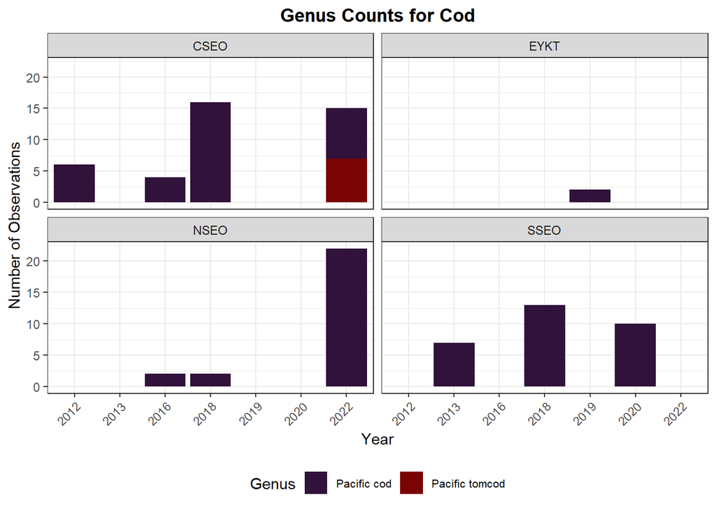

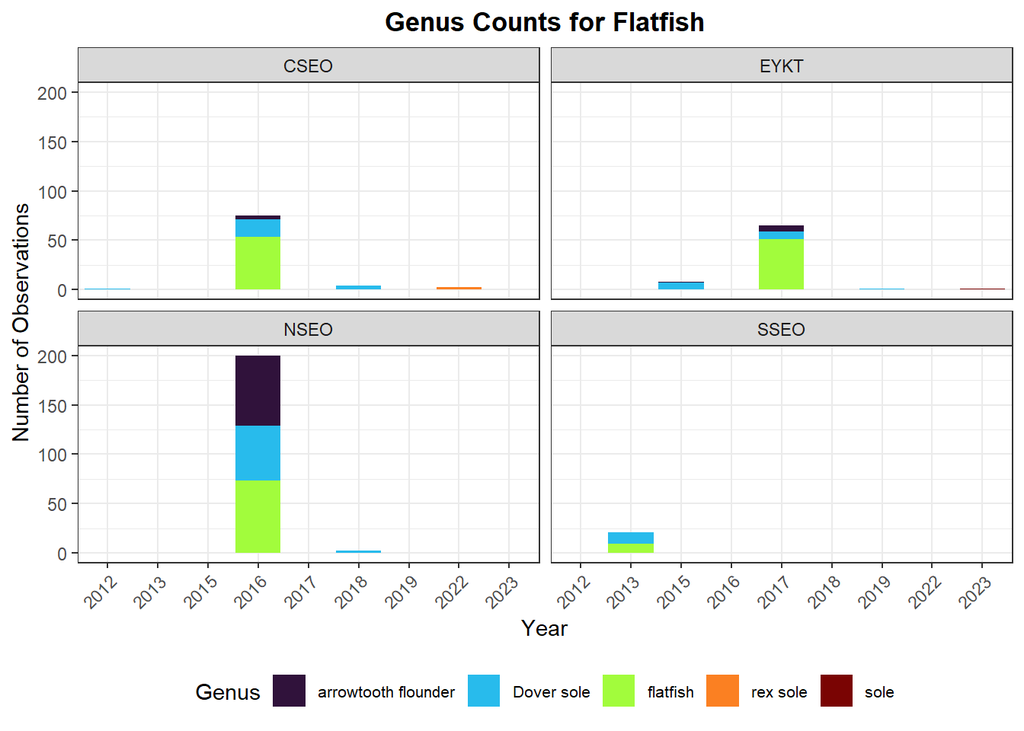

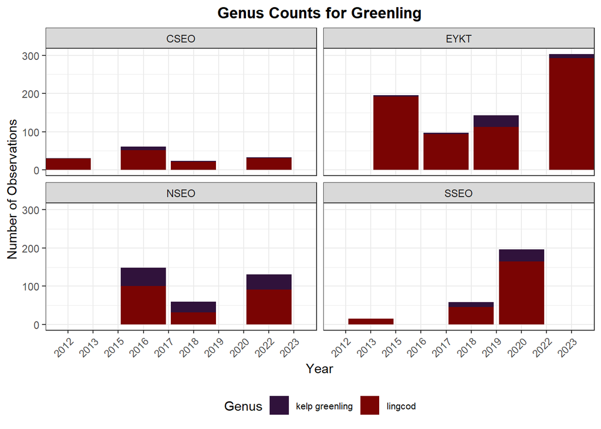

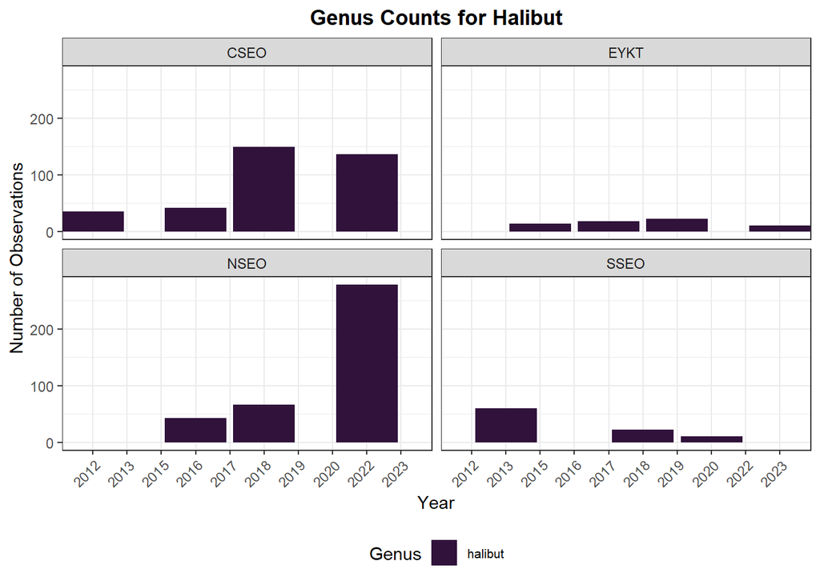

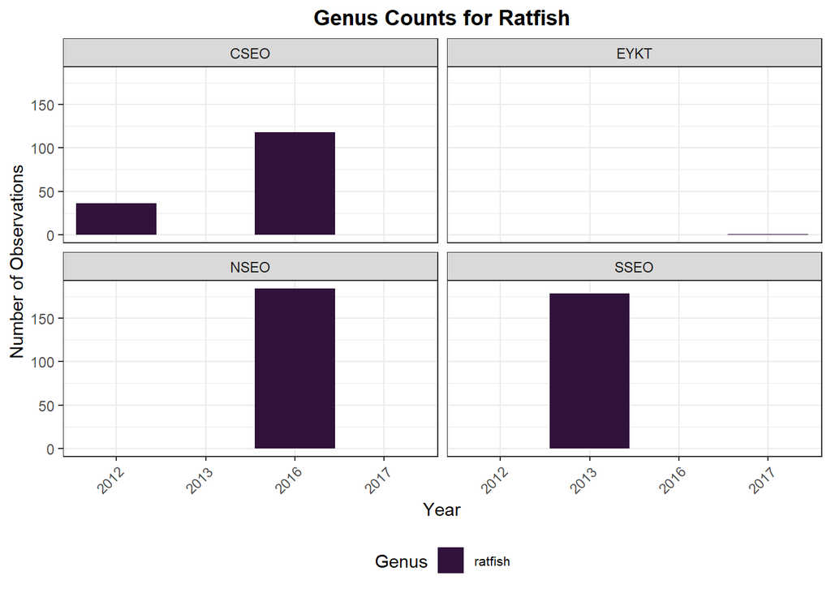

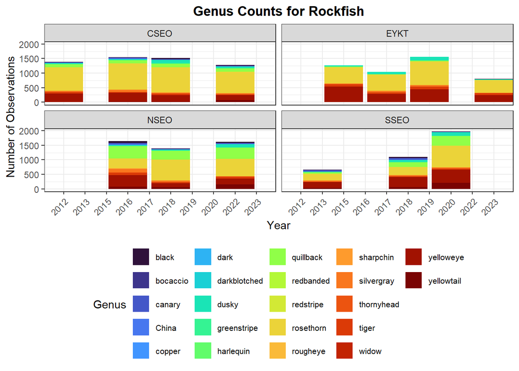

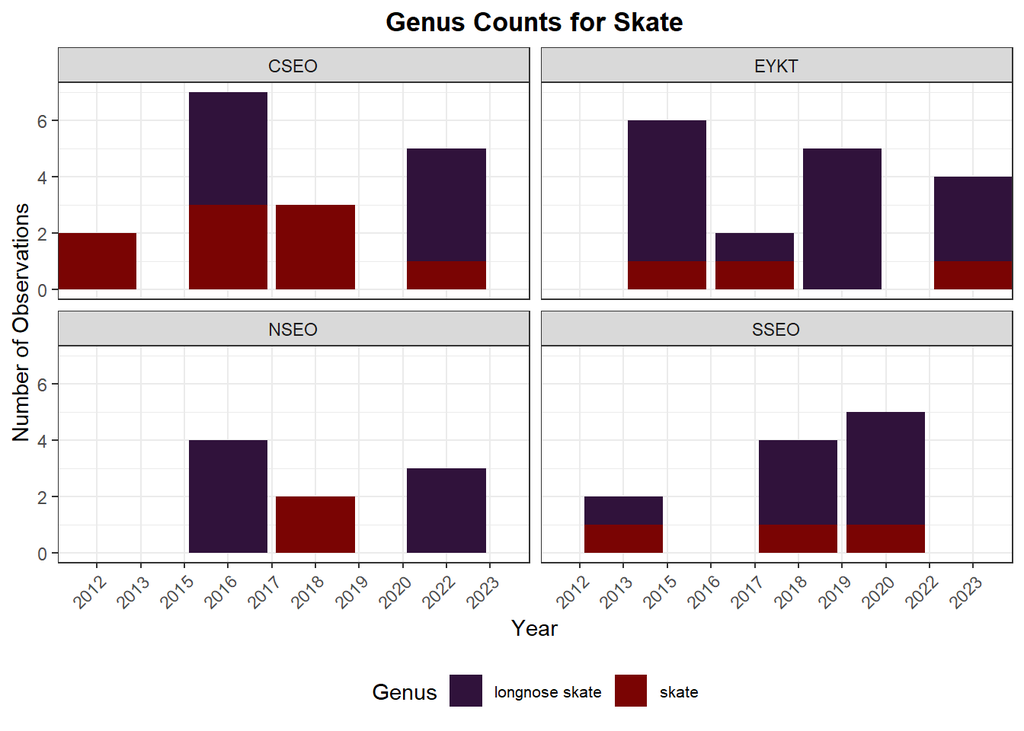

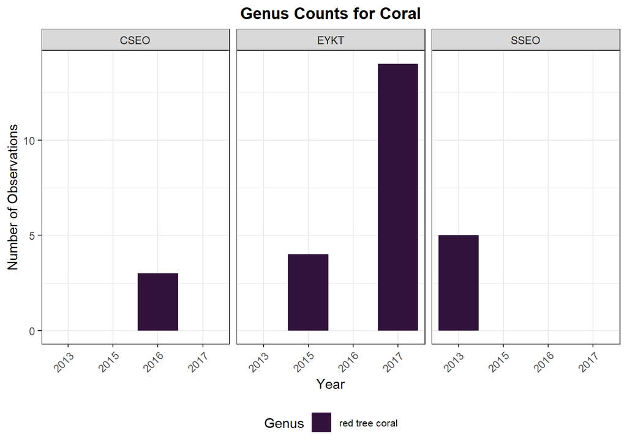

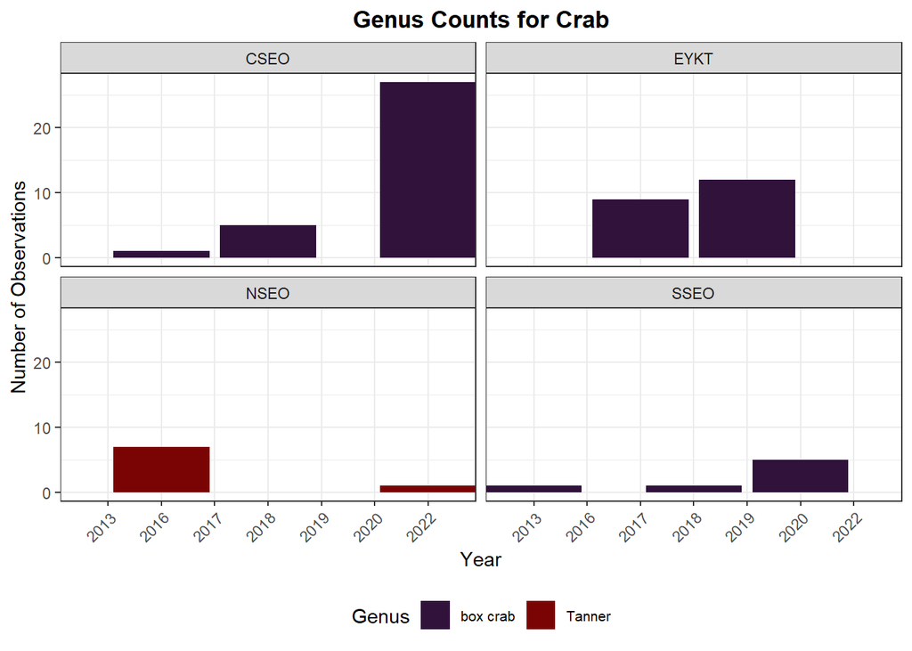

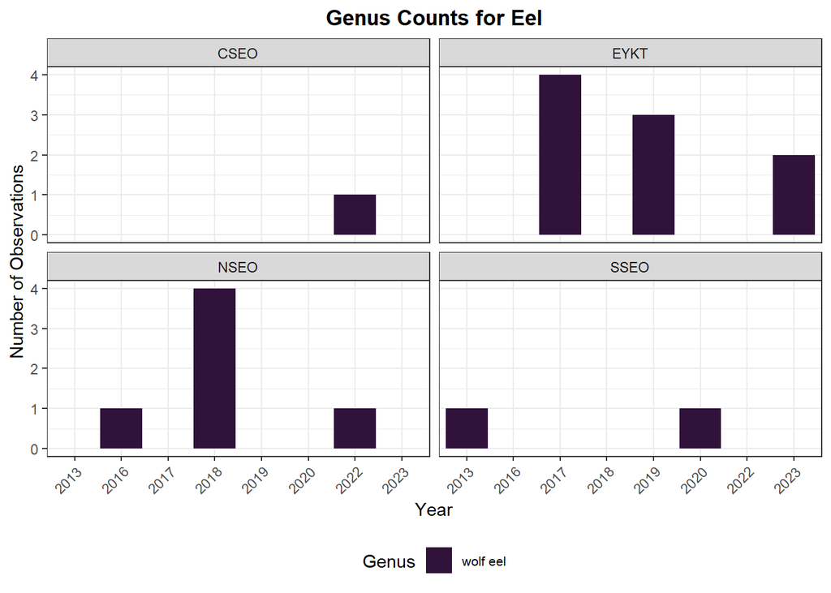

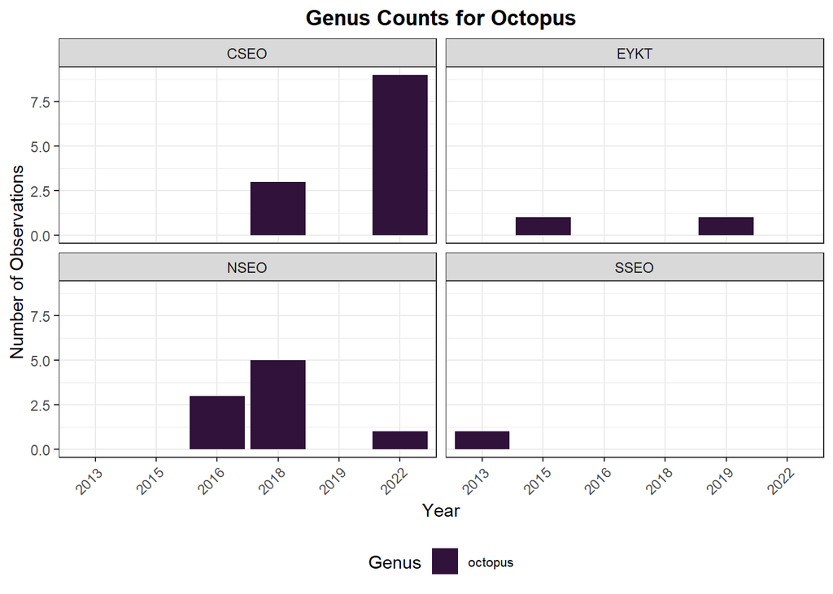

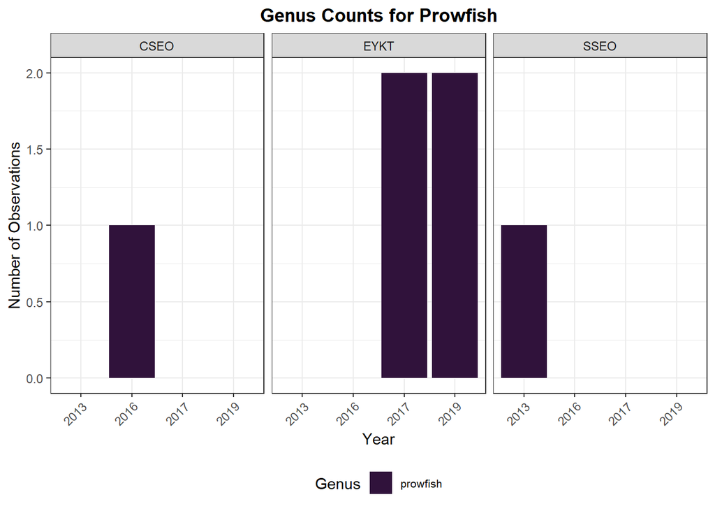

[10 more figures not shown]

```r
species_counts <- ROV_species_review_all_years %>%
  filter(!is.na(family),
         !is.na(genus),
         !is.na(species),
         !is.na(year),
         !is.na(mgmt_area),
         !genus %in% c("unknown", "uknown", "NA", "")) %>%
  group_by(family, genus, species) %>%
  summarise(n = n(), .groups = "drop")

species_counts_by_area <- ROV_species_review_all_years %>%
  filter(!is.na(family),
         !is.na(genus),
         !is.na(species),
         !is.na(year),
         !is.na(mgmt_area),
         !genus %in% c("unknown", "uknown", "NA", "")) %>%
  group_by(year, mgmt_area, family, genus, species) %>%
  summarise(n = n(), .groups = "drop")

families <- species_counts_by_area %>%
  filter(family != "") %>%
  distinct(family) %>%
  pull(family)

for(fam in families){

  p <- species_counts_by_area %>%
    filter(family == fam) %>%
    ggplot(aes(x = factor(year), y = n, fill = genus)) +
    geom_col() +
    facet_wrap(~mgmt_area) +
    scale_fill_viridis_d(option = "turbo") +
    labs(
      title = paste("Genus Counts for", tools::toTitleCase(fam)),
      x = "Year",
      y = "Number of Observations",
      fill = "Genus"
    ) +
    theme_bw() +
    theme(
      plot.title = element_text(face = "bold", hjust = 0.5),
      legend.position = "bottom",
      legend.text = element_text(size = 8),
      axis.text.x = element_text(angle = 45, hjust = 1)
    )

  print(p)
}
```

## DSR, BRF, Halibut, Lingcod

We only collect length data for DSR, black rockfish (since 2018), halibut and lingcod.

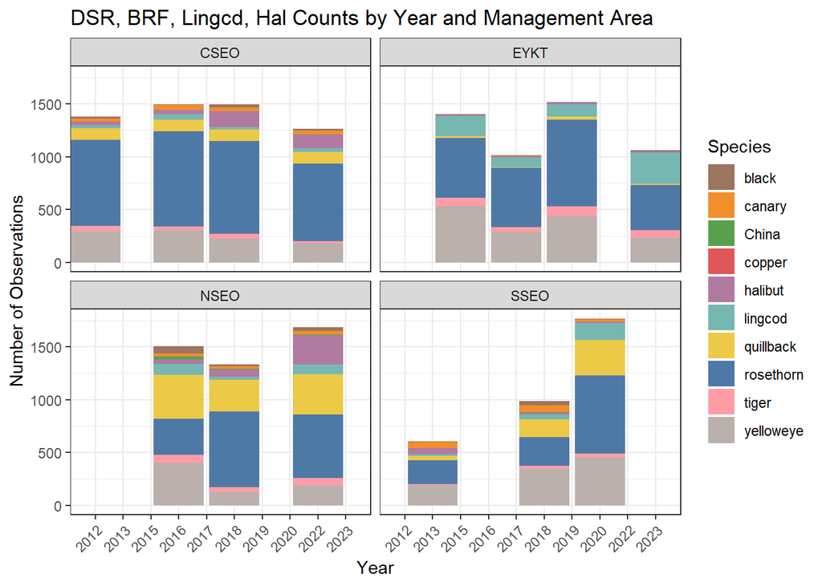

```r
species_counts_by_area %>%
  filter(genus %in% c("rosethorn",
                      "quillback",
                      "yelloweye",
                      "tiger",
                      "canary",
                      "copper",
                      "China",
                      "lingcod",
                      "black",
                      "halibut")) %>%
ggplot(aes(x = factor(year), y = n, fill = factor(genus))) +
  geom_col(position = "stack") +
  facet_wrap(~ mgmt_area) +
  labs(
    x = "Year",
    y = "Number of Observations",
    fill = "Species",
    title = "DSR, BRF, Lingcd, Hal Counts by Year and Management Area") +
  theme_bw()+
  scale_fill_manual(values = c(
  "#9C755F",  # brown
  "#F28E2B",  # orange
  "#59A14F",  # green
  "#E15759",  # red
  "#B07AA1",  # purple
  "#76B7B2",  # teal
  "#EDC948",  # yellow
  "#4E79A7",  # blue
  "#FF9DA7",  # pink
  "#BAB0AC"   # gray
))+
  theme(axis.text.x = element_text(angle = 45, hjust = 1, vjust = 1))
```

## DSR

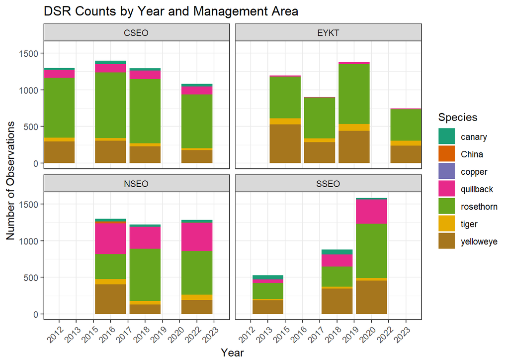

```r
species_counts_by_area %>%
  filter(genus %in% c("rosethorn",
                      "quillback",
                      "yelloweye",
                      "tiger",
                      "canary",
                      "copper",
                      "China")) %>%
ggplot(aes(x = factor(year), y = n, fill = factor(genus))) +
  geom_col(position = "stack") +
  facet_wrap(~ mgmt_area) +
  labs(
    x = "Year",
    y = "Number of Observations",
    fill = "Species",
    title = "DSR Counts by Year and Management Area") +
  theme_bw()+
  scale_fill_brewer(palette = "Dark2") +
  theme(axis.text.x = element_text(angle = 45, hjust = 1, vjust = 1))
```

# Activity Analysis

Since the adoption of the ROV in 2012, an average of 78% of all yelloweye rockfish from the surveys moved minimally or slowly. Of those slow-moving specimens, approximately 70% did not display directional movements (i.e., they were milling or resting on the bottom).

The above text is from the draft of the ROP. I am assuming Kelli or Phil completed it, but I don’t know where this analysis was done. Below I replicated this analysis and updated the statement above in the ROP, which should be published in 2026.

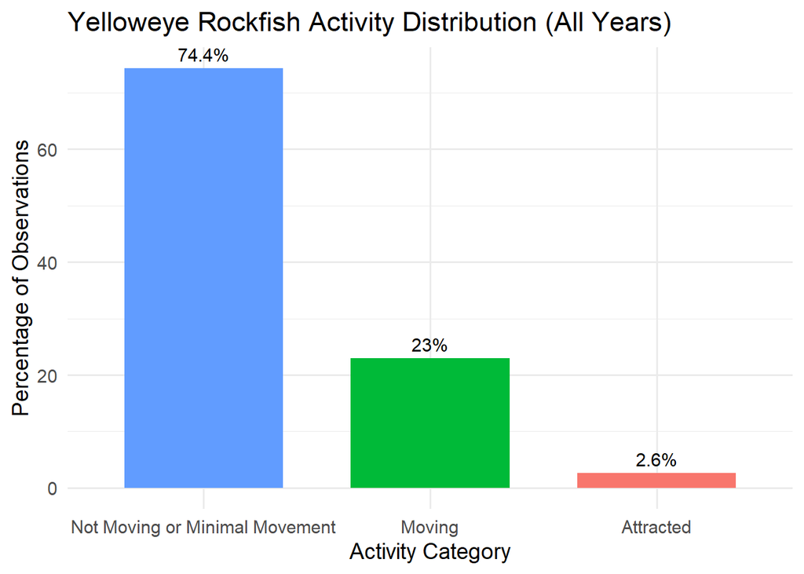

```r
activity <- ROV_species_review_all_years %>%
  filter(genus=="yelloweye",
         !activity %in% c(""," "),
         !is.na(activity)) %>%
  mutate(activity_new = case_when(
    activity %in% c("Fish milling/hovering",
                    "Fish resting on bottom",
                    "Fish moving slowly into frame",
                    "Fish moving slowly out of frame",
                    "Fish milling")~ "Not Moving or Minimal Movement",
    activity %in% c("Fish actively swimming in frame",
                    "Fish chasing other fish",
                    "Fish moving quickly into frame",
                    "Fish seeking cover",
                    "Fish being chased",
                    "Fish moving quickly out of frame",
                    "Fish actively swimming within frame",
                    "Feeding",
                    "Passing") ~ "Moving",
    activity == "Attracted" ~ "Attracted",
    TRUE ~ activity)) %>%
  group_by(activity_new) %>%
  summarize(count = n()) %>%
  mutate(percentage = (count / sum(count)) * 100) %>%
  arrange(desc(percentage))

# Overall activity distribution
ggplot(activity, aes(x = reorder(activity_new, -percentage), y = percentage, fill = activity_new)) +
  geom_bar(stat = "identity", width = 0.7) +
  geom_text(aes(label = paste0(round(percentage, 1), "%")),
            vjust = -0.5, size = 4) +
  labs(title = "Yelloweye Rockfish Activity Distribution (All Years)",
    x = "Activity Category",
    y = "Percentage of Observations",
    fill = "Activity") +
  theme_minimal(base_size = 14) +
  theme(legend.position = "none")
```

It’s important to note that the activity attribute “Attracted” was not in the ROV data until 2018 and according to the R code, those fish were not being excluded from Distance analysis until 2020.

```r
attracted <- ROV_species_review_all_years %>%
  filter(genus=="yelloweye",
         !activity %in% c(""," "),
         !is.na(activity)) %>%
  mutate(activity_new = case_when(
    activity %in% c("Fish milling/hovering",
                    "Fish resting on bottom",
                    "Fish moving slowly into frame",
                    "Fish moving slowly out of frame",
                    "Fish milling")~ "Not Moving or Minimal Movement",
    activity %in% c("Fish actively swimming in frame",
                    "Fish chasing other fish",
                    "Fish moving quickly into frame",
                    "Fish seeking cover",
                    "Fish being chased",
                    "Fish moving quickly out of frame",
                    "Fish actively swimming within frame",
                    "Feeding",
                    "Passing") ~ "Moving",
    activity == "Attracted" ~ "Attracted",
    TRUE ~ activity)) %>%
  filter(activity == "Attracted") %>%
  group_by(year, mgmt_area) %>%
  summarize(count = n())
```